# Replication of Study 3 in “Anticipating divine protection? Reminders of god can increase nonmoral risk taking” by Kupor, D. M., Laurin, K., & Levav, J. (Psychological Science 26.4 (2015): 374-384)

Katherine Flaschen (kflasche@stanford.edu)

## Introduction

Kupor, Laurin, and Levav (2015) demonstrated that priming God increased people’s willingness to take nonmoral risks. Further, they showed that this effect was mediated by perceived risk. Specifically, reminders of God (as opposed to a control condition) led individuals to perceive nonmoral risk as less dangerous, which in turn led to an increased willingness to take such risk. The authors suggested that reminders of God led to less perceived risk because such reminders evoked a feeling of safety from potential harm, although this was tested more directly in a subsequent study.

The original paper can be found here:  
http://pss.sagepub.com/content/26/4/374.full.pdf  
The supplemental material can be found here: http://pss.sagepub.com/content/suppl/2015/02/25/0956797614563108.DC1/DS_10.11770956797614563108.pdf

## Methods

### Power Analysis

The original study’s **key result** was a mediation analysis, with willingness to take risks as the dependent variable, priming condition as the independent variable, and perceived risk as the mediating variable:

1. Participants in the God condition reported a higher willingness to take risks, *b* = .61, *t*(99) = 2.29, *p* = .024, than did participants in the control condition.
2. Participants in the God condition also perceived less danger associated with these risks, *b* = -0.44, *t*(99) = -2.97, *p* = .004, than did participants in the control condition.
3. When the effects of God condition and perceived danger were both included in the model, the indirect effect (i.e., through the mediator) was significant (95% confidence interval, or CI = [0.12, 0.64]), whereas the direct effect (i.e., the effect of condition independent of the mediator) was not significant, *b* = 0.28, *t*(98) = 1.12, *p* = .267.

Because I didn’t have enough information to calculate the effect size of the indirect effect, I calculated the effect size for the IV’s effect on the DV, as well as the effect size for the IV’s effect on the mediator:

1. *b* = .61, *t*(99) = 2.29, *p* = .02 (Cohen’s d = .46)
2. *b* = -0.44, *t*(99) = -2.97, *p* = .004 (Cohen’s d = .60)

Then, I took the smaller of these two effect sizes, Cohen’s d = .46, for my power analysis:

```r
power.t.test(delta=0.46, sd=1, power=.80, sig.level=0.05)
```

```
##
##      Two-sample t test power calculation
##
##               n = 75.15854
##           delta = 0.46
##              sd = 1
##       sig.level = 0.05
##           power = 0.8
##     alternative = two.sided
##
## NOTE: n is number in *each* group
```

### Planned Sample

The original study uses a sample size of 101 participants, which, from a post hoc analysis, results in 63% power. Therefore, I have chosen to run my replication with 160 participants, which is the number of participants needed to achieve 80% power (plus a buffer of 5% for exclusions).

Like the original authors, I will have no specific criteria for participant demographics. The original study cited a mean age of 31.4 years, 64.4% male and 35.6% female.

The authors did not allow participants who had taken one of their previous experiments on God and risk taking to participate in their study. I will not need to adhere to this preselection rule, but I will exclude any participant who reports having seen any of the information used in my replication in a previous study (see d under “Differences from Original Study” section). Further, from speaking with the authors, they believe that their MTurk qualifications restricted workers to a US location, non-masters, and an 85% approval percentage. I will adhere to these qualifications.

### Materials

I was fortunate enough to have the original study shared with me by the authors. Therefore, I will adhere to the original study’s wording exactly, unless otherwise mentioned in the “Differences from Original Study” section. The bulk of the content is listed below:

**Priming Conditions:**  
God Prime Condition:  
*“God is often thought of as a supreme being. Theologians have described God as having many attributes, including omniscience (infinite knowledge), omnipotence (unlimited power), omnipresence (present everywhere), and omnibenevolence (perfect goodness). God has also been conceived as being incorporeal (immaterial), a personal being, and the ‘greatest conceivable existent.’”* (adapted from Wikipedia: http://en.wikipedia.org/wiki/God)

Control Condition:  
*“In 2006, the International Astronomers’ Union passed a resolution outlining three conditions for an object to be called a planet. First, the object must orbit the sun; second, the object must be a sphere; and third, it must have cleared the neighborhood around its orbit. Pluto does not meet the third condition, and is thus not a planet.”* (adapted from Wikipedia: http://en.wikipedia.org/wiki/Pluto)

**Nonmoral Risk Scenarios:**  
Motorcycle Scenario:  
*“Imagine that you have a motorcycle that you love to ride. It is a nice day outside, and you are planning to ride your motorcycle to a nearby park to have a picnic. Since it’s such a beautiful day out, you are thinking about riding your motorcycle without a helmet so that you can feel the wind in your face and have a better ride to the park. However, if you decide to take the risk and not wear a helmet, there is a greater chance of being injured if you get into an accident.”*

Wilderness Camping Scenario:  
*“Imagine that you are planning a trip to Guatemala, and you are looking online to see what kinds of activities you could do during your trip. You enjoy wilderness camping, and you see a website that describes a Guatemalan wilderness area that people can camp in. The wilderness area looks magnificent. You know that you would have an amazing time camping in this wilderness area. However, the website notes that if you decide to take the risk and go camping in this area, there are dangers that you could face (such as potentially dangerous wild animals and weather).”*

Backcountry Skiing Scenario:  
*“Imagine that you like to ski, and you are deciding whether or not to spend the day backcountry skiing. Backcountry skiing is skiing on an unmarked slope that is not maintained, monitored, or patrolled by anyone. You are thinking that backcountry skiing would be a great experience. However, if you decide to take the risk and go backcountry skiing, there is a chance that you could get injured by an avalanche, rock fall, or weather.”*

### Procedure

I will follow the original study’s procedure exactly, unless otherwise noted in the “Differences from Original Study” section. Is it worth noting that the “ostensibly unrelated survey” (see reference below) will be introduced in the exact same manner in my replication as in the original study. Namely, the study description and instructions page of the study will note that the session consists of two separate surveys. Additionally, the second survey will be introduced with the brief transition text, “You will now complete questions for a separate survey. Please click the next button to continue.”

The original study’s procedure is outlined below:  
“One hundred one participants (mean age = 31.4 years; 64.4% male, 35.6% female) completed this study. We obtained these participants by posting 100 HITs on MTurk. We randomly assigned participants to either the God condition or the control condition from Study 1d. In an ostensibly unrelated survey, participants read three scenarios that each described a risky decision (motorcycling without a helmet, wilderness camping, and backcountry skiing). After reading each scenario, participants completed three items assessing their perceptions of danger: “If you did [e.g., go wilderness camping], what is the likelihood that you will get injured?” (1 = extremely unlikely, 7 = extremely likely), “If you did get injured while [e.g., wilderness camping], how serious do you think the injury would be?” (1 = not serious at all, 7 = extremely serious), and “If you did get injured while [e.g., wilderness camping], how well would you be able to cope with the injury?” (1 = not well at all, 7 = extremely well; reverse coded). We created an index of the nine subjective-danger-perception items (with higher scores representing more perceived danger; α = .71). Finally, participants reported how willing they would be to take each risk (1 = not likely at all, 7 = extremely likely), which yielded an index of risk taking (α = .60).”

### Analysis Plan

The original authors did not exclude any participants from the data analysis. I will run the following analyses both on all participants (see d and e under “Differences from Original Study” section for exceptions) and only on participants who spend at least 5 seconds reading the priming (God vs. control) excerpt. Although the original authors did not do this, I think this is consistent with research best practices, as I would not expect the priming condition to have an effect on any participant who did not read the excerpt.

First, the original authors found that a linear mixed model that included scenario (three levels, dummy coded), condition, and the terms representing their interaction did not differ from the results of the model without the interaction, *χ2*(2, *N* = 101) = 1.24, *p* = .539, which indicates that scenario did not moderate the effect of condition on willingness to take risks. Therefore, the authors collapsed the perceived risk items and risk taking items across the three risky scenarios for the following analyses. Also, as an additional check, the authors performed the following mediation analysis for each scenario individually, which I will do as well. If I do indeed find that scenario moderated the effect of condition on willingness to take risks, these additional analyses will allow me to pinpoint which scenarios fit with the authors’ mediation hypothesis, and which scenarios did not.

Next, like the original authors, I will run a mediation analysis as my **main analysis**: “Our primary analysis tested the indirect effect (Hayes, 2013) using willingness to take risks as the dependent variable, priming condition (God = 1, control = 0) as the independent variable, and perceived risk as the mediating variable—this test confirmed our predictions. Specifically, participants in the God condition reported a higher willingness to take risks, *b* = 0.61, *t*(99) = 2.29, *p* = .024, and also perceived less danger associated with these risks, *b* = −0.44, *t*(99) = −2.97, *p* = .004, than did participants in the control condition. When the effects of God condition and perceived danger were both included in the model, the indirect effect (i.e., through the mediator) was significant (95% confidence interval, or CI = [0.12, 0.64]), whereas the direct effect (i.e., the effect of condition independent of the mediator) was not significant, *b* = 0.28, *t*(98) = 1.12, *p* = .267.”

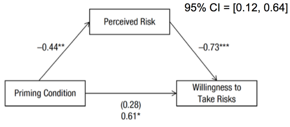

Additionally, as the authors included in their Supplemental Material, I will run the above mediation analysis three additional times, treating each item in the perceived risk index individually as the mediating variable. The authors found that, “A mediation comparison analysis (Hayes, 2013) revealed no significant differences between the indirect effects. Specifically, the analysis revealed no difference between the coping ability and the seriousness of negative consequences indirect effects (CI: -.5741 to .0569), no difference between the likelihood of negative consequences and coping ability indirect effects (CI: -.5720 to .0052), and no difference between the likelihood of negative consequences and seriousness of negative consequences indirect effects (CI: -.2844 to .1239).”

Finally, as the authors depicted in their Supplemental Material, I will use participants’ response to the question, “Do you believe in God?” (“yes” or “no”), asked at the end of the study, to determine if belief in God moderates the effect of condition on willingness to take risks. The authors found that belief in God did not moderate the effect of condition on risk taking (believers: *t*(66) = 1.54, *p* = .128; non-believers: *t*(30) = 1.69, *p* = .102).

### Differences from Original Study

Given that the original study was run on MTurk and that I have all the exact materials from the original study, I anticipate few significant differences from the original study. The differences I do anticipate are listed below:

1. Whereas the original study had a sample size of 101 participants (with 63% power), I will use a sample size of 160 participants in order to achieve 80% power (plus a buffer of 5% for exclusions). I do not anticipate that this difference will have an effect on the study’s findings, as, with more power, I should be more likely to replicate the original study’s findings.
2. The original study was framed as taking approximately 8-10 minutes. If the authors paid the standard rate on MTurk, this means that workers would have received about 80 cents for taking the original study. However, I believe that the study can be completed in 3 minutes (and have changed this in the study description and instructions page that workers will see). Therefore, workers will be paid 30 cents for completing the replication. It is possible that this could have an effect on the replication’s findings if participants are less incentivized to read information closely or answer questions accurately. However, I have limited resources for running the replication.
3. I do not have the study name or description that the authors posted on MTurk for the original study, so I will be using the study name, “Passage Reading” and the study description, “This session will take approximately 3 minutes and consists of two separate surveys. In each survey, you will be asked to read some information and then to answer several questions about the information that you have read. You will be notified before each survey begins.” Thus, the first page, or the instructions page, of the replication will be slightly different from the original study, as I will repeat this description, along with notifying the user that they should complete the study in a single sitting without distraction (as the original study did). I do not anticipate that this difference will have an effect on the study’s findings, as the instructions provided to participants in the replication will be pretty close to those provided in the original study.
4. Because I have not run any previous experiments on God and risk taking, I will not need to adhere to the authors’ preselection rule (see “Planned Sample” section). However, I added an additional question to the end of my replication (“Have you seen any of the information that you read in these two surveys in a previous survey?”). Only participants who respond “no”, rather than “yes”, will be included in my analyses. I do not anticipate that this difference will have an effect on the study’s findings, as I am simply ensuring that the workers in my replication were not participants in the original study.
5. Further, I have added one more additional question to the end of my replication (“In your opinion, what were these two surveys about?”). If any participants correctly report the hypothesis of the experiment, they will be excluded from all analyses. Although the original authors did not do this, I think that this is an important check to include given the minimal separation between the two ostensibly unrelated parts of the survey in the original study (and thus in my replication). Because I expect few participants to correctly report the hypothesis of the experiment, I do not anticipate that this difference will have an effect on the study’s findings. However, excluding such participants will help ensure that my replication’s findings are due to a real effect, rather than demand effects.
6. The authors do not specify whether or not they required that participants answer questions. I have chosen to require that participants answer questions by adding an error message (“Please answer all of the questions below before continuing to the next page”) if at least one question on a page is left unanswered. All questions will be required, except for the last page in the replication, which will consist of demographics questions and the question in d) above. For these questions, I will use an error message (“There are unanswered questions on this page. Are you sure you want to continue?”) if at least one question on the page is left unanswered, but will not prevent participants from continuing on in the study if they so choose. I do not anticipate that this difference will have an effect on the study’s findings.
7. Although the original authors did not do this, I will run my analyses both on all participants and only on participants who spend at least 5 seconds reading the priming excerpt (see “Analysis Plan”). These additional analyses will serve as an important check to make sure that MTurk workers are paying attention, which is especially important in a priming study. If many participants do not spend at least 5 seconds reading the priming information, then I would anticipate that these analyses could lead to different results (i.e. the analyses on all participants may not show the hypothesized effect).

## (Post Data Collection) Methods Addendum

### Differences from pre-data collection methods plan

None.

## Results

### Data prep

```r
path <- "~/Desktop/Classes/Winter2015/Psych254/kflascheProject/Projects/mturk/"
files <- dir(paste0(path,"production-results/"),
             pattern = "*.json")
d.raw <- data.frame(stringsAsFactors = FALSE)

for (f in files) {
  jf <- paste0(path, "production-results/",f)
  jd <- fromJSON(file=jf)
  id <- data.frame(workerid = jd$WorkerId,
                   timer = as.numeric(jd$answers$data$primetime),
                   interesting = as.numeric(paste0(jd$answers$data$condition_god, jd$answers$data$condition_control)),
                   god_thoughts = jd$answers$data$god_thoughts,
                   god_attncheck = jd$answers$data$god_attncheck,
                   control_thoughts = jd$answers$data$control_thoughts,
                   control_attncheck = jd$answers$data$control_attncheck,
                   m_perceivedrisk1 = as.numeric(jd$answers$data$mlikelihood),
                   m_perceivedrisk2 = as.numeric(jd$answers$data$mserious),
                   m_perceivedrisk3 = as.numeric(jd$answers$data$mcope),
                   m_risk = as.numeric(jd$answers$data$mlikely),
                   wc_perceivedrisk1 = as.numeric(jd$answers$data$wclikelihood),
                   wc_perceivedrisk2 = as.numeric(jd$answers$data$wcserious),
                   wc_perceivedrisk3 = as.numeric(jd$answers$data$wccope),
                   wc_risk = as.numeric(jd$answers$data$wclikely),
                   s_perceivedrisk1 = as.numeric(jd$answers$data$slikelihood),
                   s_perceivedrisk2 = as.numeric(jd$answers$data$sserious),
                   s_perceivedrisk3 = as.numeric(jd$answers$data$s_cope),
                   s_risk = as.numeric(jd$answers$data$slikely),
                   belief_god = jd$answers$data$godbelief,
                   gender = jd$answers$data$gen,
                   age = as.numeric(jd$answers$data$age),
                   race = jd$answers$data$race_ethn,
                   english = ifelse(is.null(unlist(jd$answers$data$engl)), NA,
                         unlist(jd$answers$data$engl)),
                   check_seen = jd$answers$data$previouscheck,
                   check_hypothesis = jd$answers$data$studycheck,
                   stringsAsFactors=FALSE)
  d.raw <- bind_rows(d.raw, id)
}

#Remove duplicates
d.raw = d.raw[!duplicated(d.raw$workerid), ]
```

```r
#Clean up factor structure
d.raw$belief_god <- factor(d.raw$belief_god)
levels(d.raw$belief_god) <- c("No","Yes")

d.raw$gender <- factor(d.raw$gender)
levels(d.raw$gender) <- c("Female","Male","Other")

d.raw$english <- factor(d.raw$english)
levels(d.raw$english) <- c("No","Yes")

d.raw$check_seen <- factor(d.raw$check_seen)
levels(d.raw$check_seen) <- c("No","Yes")

#Create Condition Variable
d.raw$condition <- factor(ifelse(d.raw$god_thoughts=="", "Control", "God"))
```

### Actual Sample

#### Sample Size

160 participants were recruited for this experiment.

#### Exclusion Criteria and Demographics

As specified under d and e of the “Differences from Original Study” section, 6 participants were excluded for either reporting that they had seen the study before and/or correctly reporting the hypothesis of the experiment.

This left a total of 154 participants. As specified in my analysis plan, I ran all analyses on these 154 participants (mean age = 34.1 years; 45.5% male, 53.2% female), as well as only on participants who spent at least 5 seconds reading the priming (God vs. control) excerpt, which represented 145 participants (mean age = 34.4 years; 45.5% male, 53.1% female).

### Confirmatory Analysis

#### Preliminary Analysis: Linear Mixed Models

**All participants**

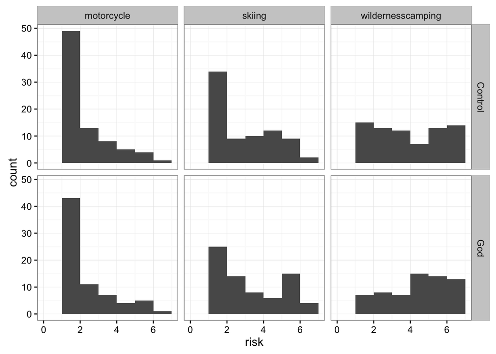

```r
#Turn data into long form
d.gathered <- d %>%
  dplyr::rename(motorcycle_perceivedrisk1 = m_perceivedrisk1,
         motorcycle_perceivedrisk2 = m_perceivedrisk2,
         motorcycle_perceivedrisk3 = m_perceivedrisk3,
         motorcycle_risk = m_risk,
         wildernesscamping_perceivedrisk1 = wc_perceivedrisk1,
         wildernesscamping_perceivedrisk2 = wc_perceivedrisk2,
         wildernesscamping_perceivedrisk3 = wc_perceivedrisk3,
         wildernesscamping_risk = wc_risk,
         skiing_perceivedrisk1 = s_perceivedrisk1,
         skiing_perceivedrisk2 = s_perceivedrisk2,
         skiing_perceivedrisk3 = s_perceivedrisk3,
         skiing_risk = s_risk) %>%
  gather(scenario, rating,
         starts_with("motorcycle_"), starts_with("wildernesscamping_"), starts_with("skiing_")) %>%
  separate(scenario, c("scenario", "risk"), "_") %>%
  spread(risk, rating)

#Histogram
#Risk-taking by scenario and condition
qplot(risk, data = d.gathered, facets=condition~scenario, binwidth=1) + theme_bw() + xlim(0,7)
```

```r
#Analysis
model1 = lmer(risk ~ condition + scenario + (1 | workerid), REML = TRUE, d.gathered)
summary(model1)
```

```
## Linear mixed model fit by REML t-tests use Satterthwaite approximations
##   to degrees of freedom [lmerMod]
## Formula: risk ~ condition + scenario + (1 | workerid)
##    Data: d.gathered
##
## REML criterion at convergence: 1785.2
##
## Scaled residuals:
##      Min       1Q   Median       3Q      Max
## -2.13496 -0.67956 -0.08258  0.62401  2.97616
##
## Random effects:
##  Groups   Name        Variance Std.Dev.
##  workerid (Intercept) 1.102    1.050
##  Residual             1.999    1.414
## Number of obs: 462, groups:  workerid, 154
##
## Fixed effects:
##                           Estimate Std. Error       df t value Pr(>|t|)
## (Intercept)                 1.8141     0.1746 274.9800  10.391  < 2e-16
## conditionGod                0.2688     0.2146 152.0000   1.253    0.212
## scenarioskiing              0.8442     0.1611 306.0000   5.239 3.02e-07
## scenariowildernesscamping   2.0714     0.1611 306.0000  12.855  < 2e-16
##
## (Intercept)               ***
## conditionGod
## scenarioskiing            ***
## scenariowildernesscamping ***
## ---
## Signif. codes:  0 '***' 0.001 '**' 0.01 '*' 0.05 '.' 0.1 ' ' 1
##
## Correlation of Fixed Effects:
##             (Intr) cndtnG scnrsk
## conditionGd -0.583
## scenariskng -0.461  0.000
## scnrwldrnss -0.461  0.000  0.500
```

```r
model2 = lmer(risk ~ condition*scenario + (1 | workerid), REML = TRUE, d.gathered)
summary(model2)
```

```
## Linear mixed model fit by REML t-tests use Satterthwaite approximations
##   to degrees of freedom [lmerMod]
## Formula: risk ~ condition * scenario + (1 | workerid)
##    Data: d.gathered
##
## REML criterion at convergence: 1783.7
##
## Scaled residuals:
##      Min       1Q   Median       3Q      Max
## -2.03503 -0.69352 -0.09548  0.62819  2.92112
##
## Random effects:
##  Groups   Name        Variance Std.Dev.
##  workerid (Intercept) 1.103    1.050
##  Residual             1.995    1.412
## Number of obs: 462, groups:  workerid, 154
##
## Fixed effects:
##                                         Estimate Std. Error        df
## (Intercept)                              1.87654    0.19557 363.80000
## conditionGod                             0.13716    0.28405 363.80000
## scenarioskiing                           0.86420    0.22193 304.00000
## scenariowildernesscamping                1.86420    0.22193 304.00000
## conditionGod:scenarioskiing             -0.04228    0.32235 304.00000
## conditionGod:scenariowildernesscamping   0.43717    0.32235 304.00000
##                                        t value Pr(>|t|)
## (Intercept)                              9.595  < 2e-16 ***
## conditionGod                             0.483 0.629484
## scenarioskiing                           3.894 0.000121 ***
## scenariowildernesscamping                8.400 1.78e-15 ***
## conditionGod:scenarioskiing             -0.131 0.895734
## conditionGod:scenariowildernesscamping   1.356 0.176038
## ---
## Signif. codes:  0 '***' 0.001 '**' 0.01 '*' 0.05 '.' 0.1 ' ' 1
##
## Correlation of Fixed Effects:
##               (Intr) cndtnG scnrsk scnrwl cndtnGd:scnrs
## conditionGd   -0.688
## scenariskng   -0.567  0.391
## scnrwldrnss   -0.567  0.391  0.500
## cndtnGd:scnrs  0.391 -0.567 -0.688 -0.344
## cndtnGd:scnrw  0.391 -0.567 -0.344 -0.688  0.500
```

```r
anova(model1, model2, refit = FALSE)
```

```
## Data: d.gathered
## Models:
## object: risk ~ condition + scenario + (1 | workerid)
## ..1: risk ~ condition * scenario + (1 | workerid)
##        Df    AIC    BIC  logLik deviance  Chisq Chi Df Pr(>Chisq)
## object  6 1797.2 1822.0 -892.62   1785.2
## ..1     8 1799.7 1832.8 -891.83   1783.7 1.5713      2     0.4558
```

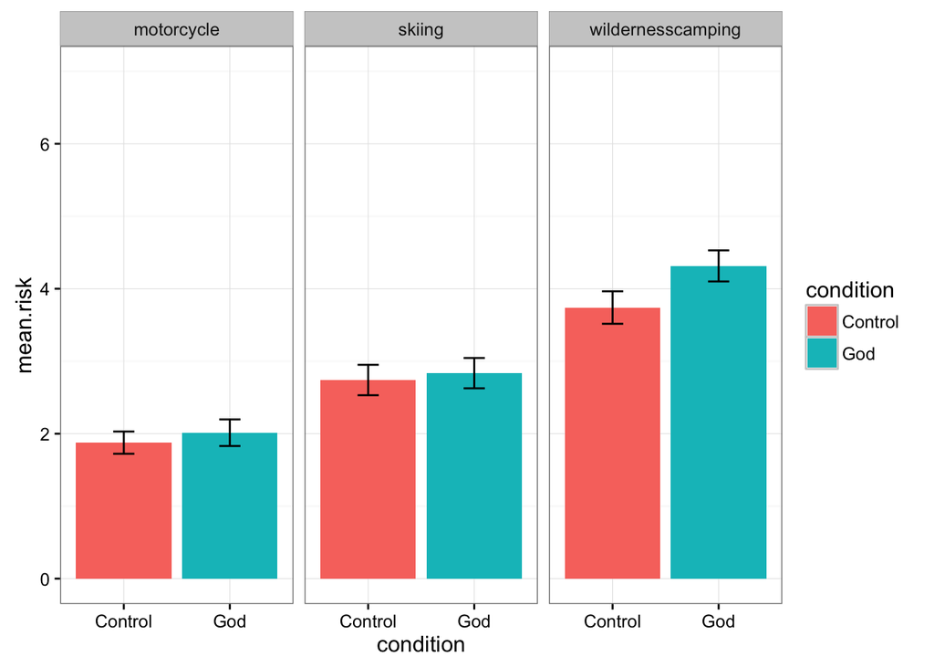

```r
#Graph
ms_LMEM_AllParticipants <- d.gathered %>%
  group_by(condition, scenario) %>%
  summarise("mean.risk" = mean(risk),
            "sem" = sem(risk),
            "ci.lower" = mean(risk) - ci95(risk),
            "ci.upper" = mean(risk) + ci95(risk))

ggplot(ms_LMEM_AllParticipants, aes(x = condition, y=mean.risk, fill=condition)) +
  geom_bar(stat="identity", position="dodge") +
  geom_errorbar(aes(ymin = mean.risk-sem,
                     ymax = mean.risk+sem), width=.2) +
  facet_wrap(~scenario) +
  theme_bw() +
  ylim(0,7)
```

**Participants who spent at least 5 seconds reading the prime**

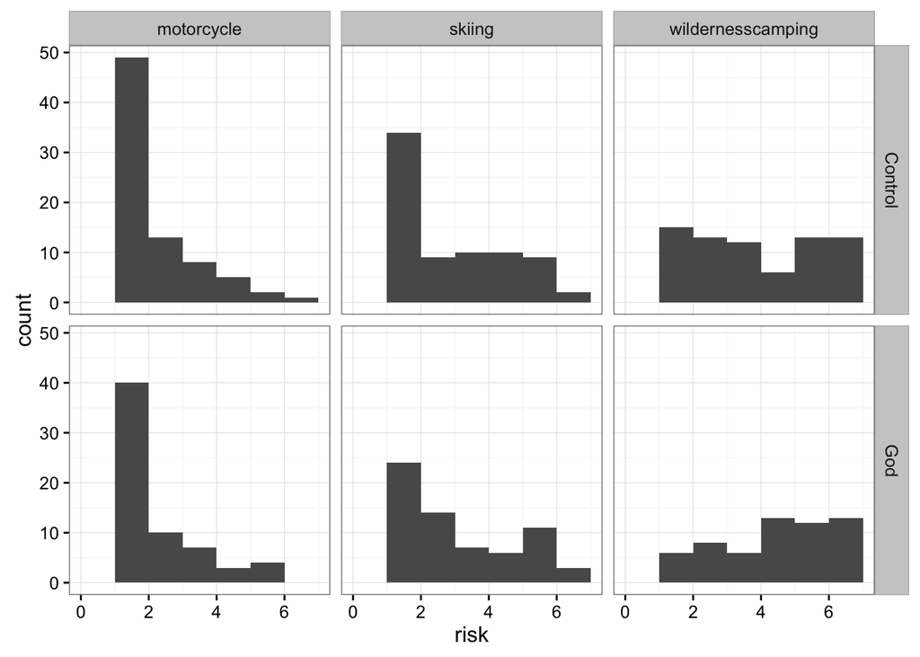

```r
#Turn data into long form
d.gathered.time <- d.time %>%
  dplyr::rename(motorcycle_perceivedrisk1 = m_perceivedrisk1,
         motorcycle_perceivedrisk2 = m_perceivedrisk2,
         motorcycle_perceivedrisk3 = m_perceivedrisk3,
         motorcycle_risk = m_risk,
         wildernesscamping_perceivedrisk1 = wc_perceivedrisk1,
         wildernesscamping_perceivedrisk2 = wc_perceivedrisk2,
         wildernesscamping_perceivedrisk3 = wc_perceivedrisk3,
         wildernesscamping_risk = wc_risk,
         skiing_perceivedrisk1 = s_perceivedrisk1,
         skiing_perceivedrisk2 = s_perceivedrisk2,
         skiing_perceivedrisk3 = s_perceivedrisk3,
         skiing_risk = s_risk) %>%
  gather(scenario, rating,
         starts_with("motorcycle_"), starts_with("wildernesscamping_"), starts_with("skiing_")) %>%
  separate(scenario, c("scenario", "risk"), "_") %>%
  spread(risk, rating)

#Histogram
#Risk-taking by scenario and condition
qplot(risk, data = d.gathered.time, facets=condition~scenario, binwidth=1) + theme_bw() + xlim(0,7)
```

```r
#Analysis
model3 = lmer(risk ~ condition + scenario + (1 | workerid), REML = TRUE, d.gathered.time)
summary(model3)
```

```
## Linear mixed model fit by REML t-tests use Satterthwaite approximations
##   to degrees of freedom [lmerMod]
## Formula: risk ~ condition + scenario + (1 | workerid)
##    Data: d.gathered.time
##
## REML criterion at convergence: 1675.2
##
## Scaled residuals:
##     Min      1Q  Median      3Q     Max
## -2.1520 -0.7066 -0.1071  0.6315  3.0092
##
## Random effects:
##  Groups   Name        Variance Std.Dev.
##  workerid (Intercept) 1.035    1.017
##  Residual             1.999    1.414
## Number of obs: 435, groups:  workerid, 145
##
## Fixed effects:
##                           Estimate Std. Error       df t value Pr(>|t|)
## (Intercept)                 1.7453     0.1753 266.9700   9.958  < 2e-16
## conditionGod                0.2414     0.2175 143.0000   1.110    0.269
## scenarioskiing              0.8414     0.1660 288.0000   5.067 7.22e-07
## scenariowildernesscamping   2.1379     0.1660 288.0000  12.876  < 2e-16
##
## (Intercept)               ***
## conditionGod
## scenarioskiing            ***
## scenariowildernesscamping ***
## ---
## Signif. codes:  0 '***' 0.001 '**' 0.01 '*' 0.05 '.' 0.1 ' ' 1
##
## Correlation of Fixed Effects:
##             (Intr) cndtnG scnrsk
## conditionGd -0.565
## scenariskng -0.474  0.000
## scnrwldrnss -0.474  0.000  0.500
```

```r
model4 = lmer(risk ~ condition*scenario + (1 | workerid), REML = TRUE, d.gathered.time)
summary(model4)
```

```
## Linear mixed model fit by REML t-tests use Satterthwaite approximations
##   to degrees of freedom [lmerMod]
## Formula: risk ~ condition * scenario + (1 | workerid)
##    Data: d.gathered.time
##
## REML criterion at convergence: 1672.1
##
## Scaled residuals:
##      Min       1Q   Median       3Q      Max
## -2.03697 -0.67964 -0.08558  0.60969  2.93336
##
## Random effects:
##  Groups   Name        Variance Std.Dev.
##  workerid (Intercept) 1.040    1.020
##  Residual             1.983    1.408
## Number of obs: 435, groups:  workerid, 145
##
## Fixed effects:
##                                        Estimate Std. Error       df
## (Intercept)                              1.7975     0.1956 346.9000
## conditionGod                             0.1268     0.2900 346.9000
## scenarioskiing                           0.9114     0.2241 286.0000
## scenariowildernesscamping                1.9114     0.2241 286.0000
## conditionGod:scenarioskiing             -0.1538     0.3321 286.0000
## conditionGod:scenariowildernesscamping   0.4977     0.3321 286.0000
##                                        t value Pr(>|t|)
## (Intercept)                              9.188  < 2e-16 ***
## conditionGod                             0.437    0.662
## scenarioskiing                           4.067 6.16e-05 ***
## scenariowildernesscamping                8.530 8.88e-16 ***
## conditionGod:scenarioskiing             -0.463    0.644
## conditionGod:scenariowildernesscamping   1.498    0.135
## ---
## Signif. codes:  0 '***' 0.001 '**' 0.01 '*' 0.05 '.' 0.1 ' ' 1
##
## Correlation of Fixed Effects:
##               (Intr) cndtnG scnrsk scnrwl cndtnGd:scnrs
## conditionGd   -0.675
## scenariskng   -0.573  0.386
## scnrwldrnss   -0.573  0.386  0.500
## cndtnGd:scnrs  0.386 -0.573 -0.675 -0.337
## cndtnGd:scnrw  0.386 -0.573 -0.337 -0.675  0.500
```

```r
anova(model3, model4, refit = FALSE)
```

```
## Data: d.gathered.time
## Models:
## object: risk ~ condition + scenario + (1 | workerid)
## ..1: risk ~ condition * scenario + (1 | workerid)
##        Df    AIC    BIC  logLik deviance  Chisq Chi Df Pr(>Chisq)
## object  6 1687.2 1711.7 -837.61   1675.2
## ..1     8 1688.0 1720.7 -836.03   1672.0 3.1759      2     0.2043
```

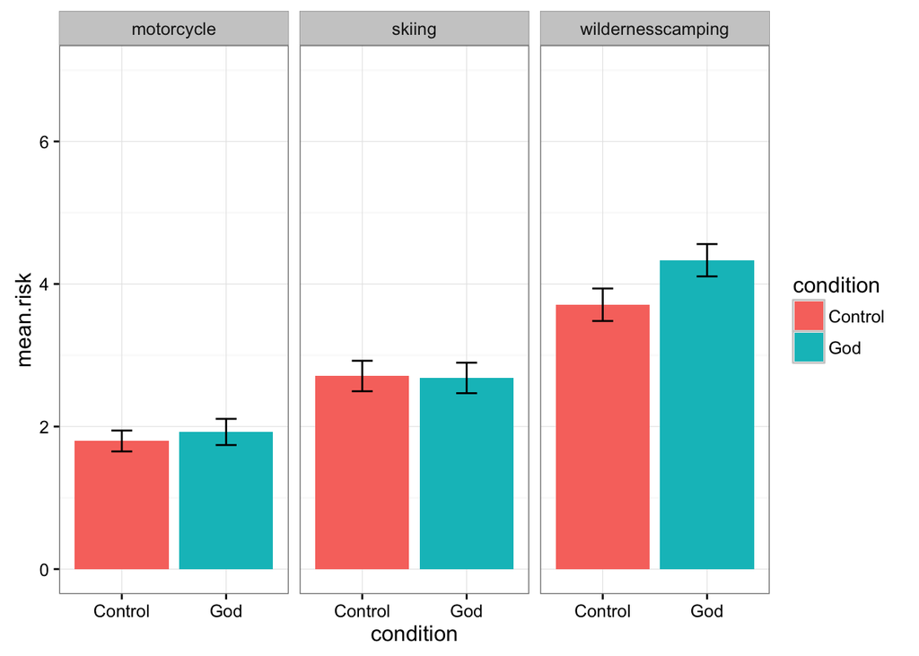

```r
#Graph
ms_LMEM_TimeExclusion <- d.gathered.time %>%
  group_by(condition, scenario) %>%
  summarise("mean.risk" = mean(risk),
            "sem" = sem(risk),
            "ci.lower" = mean(risk) - ci95(risk),
            "ci.upper" = mean(risk) + ci95(risk))

ggplot(ms_LMEM_TimeExclusion, aes(x = condition, y=mean.risk, fill=condition)) +
  geom_bar(stat="identity", position="dodge") +
  geom_errorbar(aes(ymin = mean.risk-sem,
                     ymax = mean.risk+sem), width=.2) +
  facet_wrap(~scenario) +
  theme_bw() +
  ylim(0,7)
```

#### Main Analysis: Mediation

**All participants**

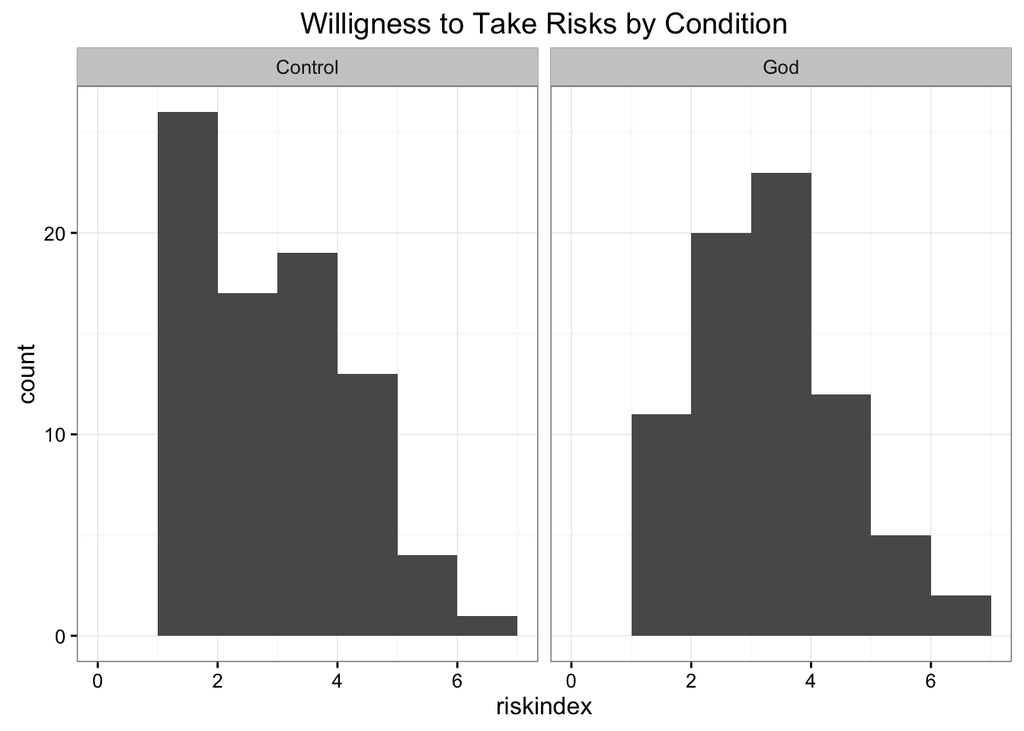

```r
#Histograms
#Risk by Condition
qplot(riskindex, data = d, facets=~condition, binwidth=1) + theme_bw() + xlim(0,7) + ggtitle("Willigness to Take Risks by Condition")
```

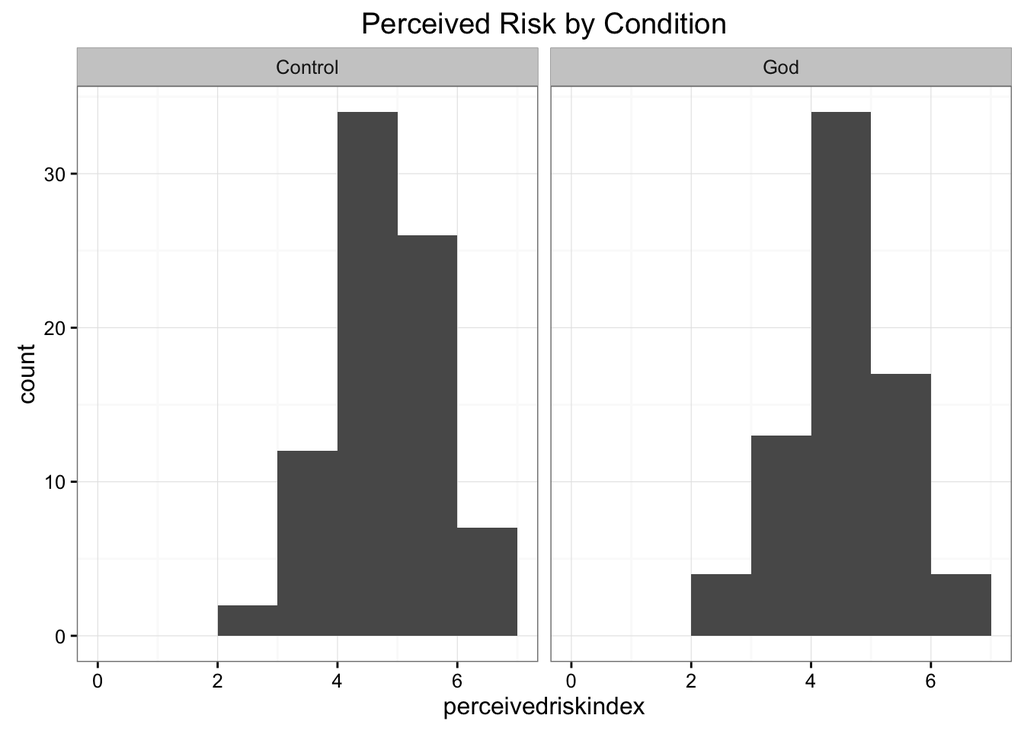

```r
#Perceived Risk by Condition
qplot(perceivedriskindex, data = d, facets=~condition, binwidth=1) + theme_bw() + xlim(0,7) + ggtitle("Perceived Risk by Condition")
```

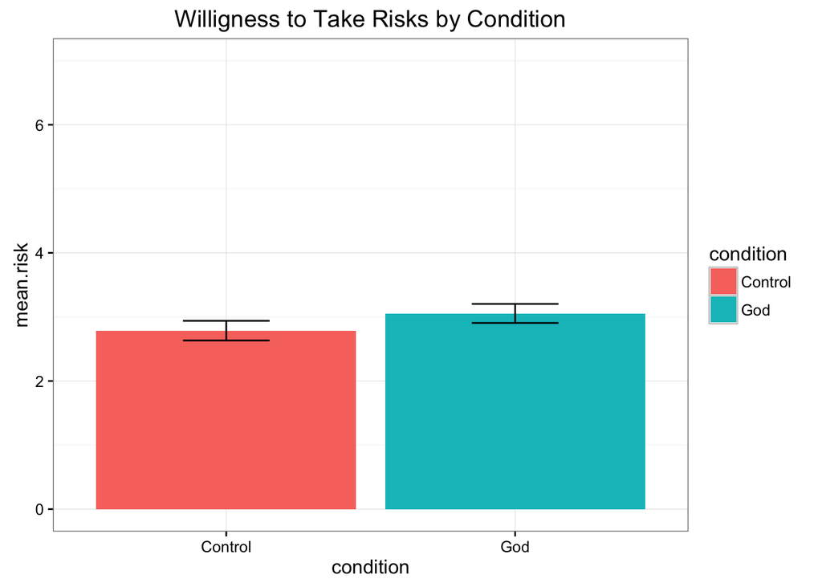

```r
#Graphs
ms_MainMediation_AllParticipants <- d %>%
  group_by(condition) %>%
  summarise("mean.risk" = mean(riskindex),
            "sem.risk" = sem(riskindex),
            "ci.lower.risk" = mean(riskindex) - ci95(riskindex),
            "ci.upper.risk" = mean(riskindex) + ci95(riskindex),
            "mean.perceivedrisk" = mean(perceivedriskindex),
            "sem.perceivedrisk" = sem(perceivedriskindex),
            "ci.lower.perceivedrisk" = mean(perceivedriskindex) - ci95(perceivedriskindex),
            "ci.upper.perceivedrisk" = mean(perceivedriskindex) + ci95(perceivedriskindex))

#Risk
ggplot(ms_MainMediation_AllParticipants, aes(x = condition, y=mean.risk, fill=condition)) +
  geom_bar(stat="identity", position="dodge") +
  geom_errorbar(aes(ymin = mean.risk-sem.risk,
                     ymax = mean.risk+sem.risk), width = .3) +
  theme_bw() +
  ylim(0,7) +
  ggtitle("Willigness to Take Risks by Condition")
```

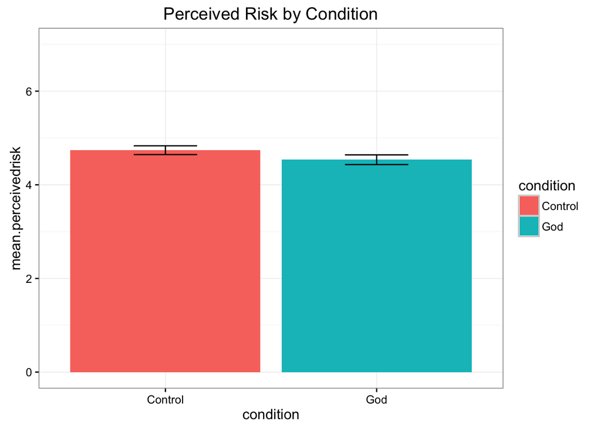

```r
#Perceived Risk
ggplot(ms_MainMediation_AllParticipants, aes(x = condition, y=mean.perceivedrisk, fill=condition)) +
  geom_bar(stat="identity", position="dodge") +
  geom_errorbar(aes(ymin = mean.perceivedrisk-sem.perceivedrisk,
                     ymax = mean.perceivedrisk+sem.perceivedrisk), width = .3) +
  theme_bw() +
  ylim(0,7) +
  ggtitle("Perceived Risk by Condition")
```

**KEY RESULT TO BE REPLICATED**

```r
#Sobel
sobel = sobel(d$condition, d$perceivedriskindex, d$riskindex)
sobel_chart <- sob_print(sobel)
kable(sobel_chart$Models)
```

|  | Estimate | Std. Error | t value | Pr(>\|t\|) |
| --- | --- | --- | --- | --- |
| Mod1: Y~X | 2.7860082 | 0.1477408 | 18.8574045 | 0.0000000 |
| predGod | 0.2687863 | 0.2145850 | 1.2525864 | 0.2122800 |
| Mod2: Y~X+M | 6.9193756 | 0.5036700 | 13.7379146 | 0.0000000 |
| predGod | 0.0912194 | 0.1785778 | 0.5108103 | 0.6102299 |
| med | -0.8721345 | 0.1031038 | -8.4588044 | 0.0000000 |
| Mod3: M~X | 4.7393690 | 0.0960530 | 49.3411970 | 0.0000000 |
| predGod | -0.2036004 | 0.1395114 | -1.4593812 | 0.1465238 |

```r
kable(sobel_chart$Vals)
```

| IndirectEffect | SE | Z | N |
| --- | --- | --- | --- |
| 0.1775669 | 0.1234703 | 1.438135 | 154 |

```r
#Bootstrapping
mediation(x = as.numeric(d$condition), mediator = d$perceivedriskindex, dv = d$riskindex, conf.level=.95, bootstrap=TRUE, B=5000)
```

```
## [1] "Bootstrap resampling has begun. This process may take a considerable amount of time if the number of replications is large, which is optimal for the bootstrap procedure."
```

```
##                                            Estimate CI.Lower_Percentile
## Indirect.Effect                         0.177566898       -5.717351e-02
## Indirect.Effect.Partially.Standardized  0.133294735       -4.295105e-02
## Index.of.Mediation                      0.066774533       -2.136270e-02
## R2_4.5                                  0.009056273       -7.357643e-03
## R2_4.6                                  0.004442614        2.257480e-05
## R2_4.7                                  0.013526535        6.797489e-05
## Ratio.of.Indirect.to.Total.Effect       0.660624834       -2.733867e+00
## Ratio.of.Indirect.to.Direct.Effect      1.946591561       -1.297494e+01
## Success.of.Surrogate.Endpoint          -1.320166128       -7.585208e+00
## Residual.Based_Gamma                    0.012290143       -3.724076e-03
## Residual.Based.Standardized_gamma       0.012888979       -2.657558e-03
## SOS                                     0.886416013       -4.048723e+01
##                                        CI.Upper_Percentile  CI.Lower_BCa
## Indirect.Effect                                 0.42898358 -5.355900e-02
## Indirect.Effect.Partially.Standardized          0.31642410 -4.295729e-02
## Index.of.Mediation                              0.15849165 -2.107953e-02
## R2_4.5                                          0.04882337 -4.870848e-03
## R2_4.6                                          0.02438012  2.112576e-05
## R2_4.7                                          0.06834756  5.998451e-05
## Ratio.of.Indirect.to.Total.Effect               4.12639656 -9.118629e-01
## Ratio.of.Indirect.to.Direct.Effect             17.79119519  1.679093e-01
## Success.of.Surrogate.Endpoint                   4.30837150 -1.371641e+01
## Residual.Based_Gamma                            0.04605057 -7.013717e-04
## Residual.Based.Standardized_gamma               0.04810552 -4.558204e-04
## SOS                                             0.99900064 -3.127481e-02
##                                        CI.Upper_BCa
## Indirect.Effect                        4.345941e-01
## Indirect.Effect.Partially.Standardized 3.164065e-01
## Index.of.Mediation                     1.585862e-01
## R2_4.5                                 5.566017e-02
## R2_4.6                                 2.413689e-02
## R2_4.7                                 6.748126e-02
## Ratio.of.Indirect.to.Total.Effect      8.197911e+00
## Ratio.of.Indirect.to.Direct.Effect     1.816047e+03
## Success.of.Surrogate.Endpoint          1.879382e+00
## Residual.Based_Gamma                   6.035768e-02
## Residual.Based.Standardized_gamma      6.074135e-02
## SOS                                    9.999977e-01
```

**Participants who spent at least 5 seconds reading the prime**

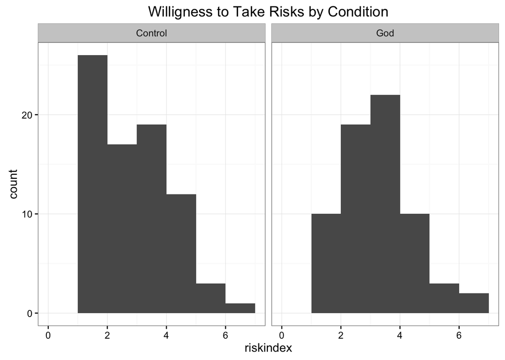

```r
#Histograms
#Risk by Condition
qplot(riskindex, data = d.time, facets=~condition, binwidth=1) + theme_bw() + xlim(0,7) + ggtitle("Willigness to Take Risks by Condition")
```

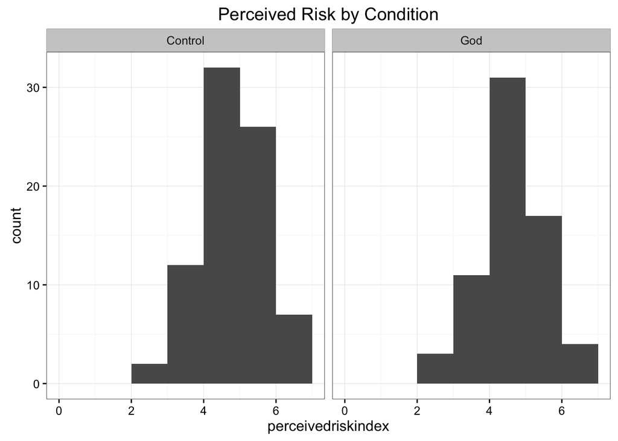

```r
#Perceived Risk by Condition
qplot(perceivedriskindex, data = d.time, facets=~condition, binwidth=1) + theme_bw() + xlim(0,7) + ggtitle("Perceived Risk by Condition")
```

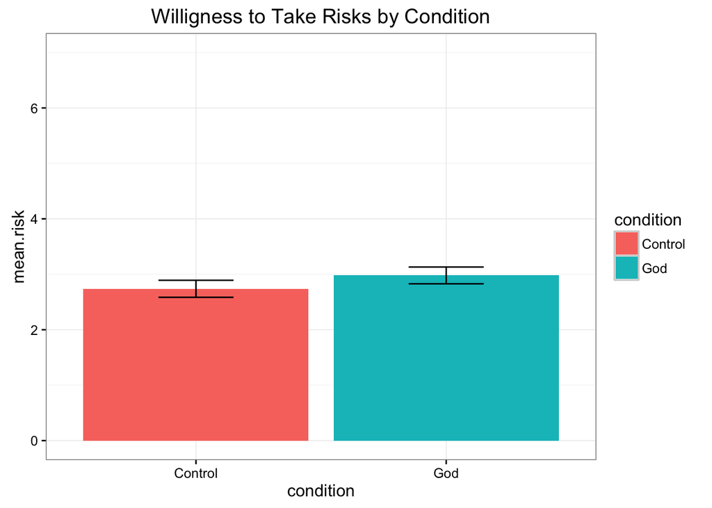

```r
#Graphs
ms_MainMediation_TimeExclusion <- d.time %>%
  group_by(condition) %>%
  summarise("mean.risk" = mean(riskindex),
            "sem.risk" = sem(riskindex),
            "ci.lower.risk" = mean(riskindex) - ci95(riskindex),
            "ci.upper.risk" = mean(riskindex) + ci95(riskindex),
            "mean.perceivedrisk" = mean(perceivedriskindex),
            "sem.perceivedrisk" = sem(perceivedriskindex),
            "ci.lower.perceivedrisk" = mean(perceivedriskindex) - ci95(perceivedriskindex),
            "ci.upper.perceivedrisk" = mean(perceivedriskindex) + ci95(perceivedriskindex))

#Risk
ggplot(ms_MainMediation_TimeExclusion, aes(x = condition, y=mean.risk, fill=condition)) +
  geom_bar(stat="identity", position="dodge") +
  geom_errorbar(aes(ymin = mean.risk-sem.risk,
                     ymax = mean.risk+sem.risk), width=.3) +
  theme_bw() +
  ylim(0,7) +
  ggtitle("Willigness to Take Risks by Condition")
```

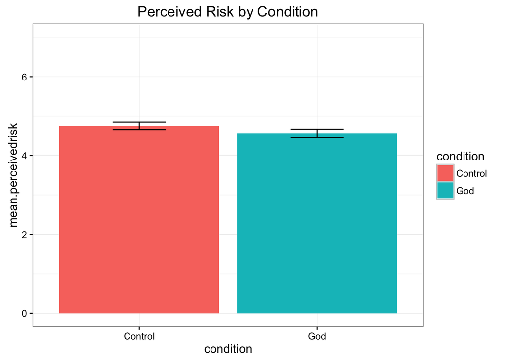

```r
#Perceived Risk
ggplot(ms_MainMediation_TimeExclusion, aes(x = condition, y=mean.perceivedrisk, fill=condition)) +
  geom_bar(stat="identity", position="dodge") +
  geom_errorbar(aes(ymin = mean.perceivedrisk-sem.perceivedrisk,
                     ymax = mean.perceivedrisk+sem.perceivedrisk), width=.3) +
  theme_bw() +
  ylim(0,7) +
  ggtitle("Perceived Risk by Condition")
```

```r
#Sobel
sobel = sobel(d.time$condition, d.time$perceivedriskindex, d.time$riskindex)
sobel_chart <- sob_print(sobel)
kable(sobel_chart$Models)
```

|  | Estimate | Std. Error | t value | Pr(>\|t\|) |
| --- | --- | --- | --- | --- |
| Mod1: Y~X | 2.7383966 | 0.1467337 | 18.6623545 | 0.0000000 |
| predGod | 0.2414014 | 0.2174913 | 1.1099355 | 0.2688898 |
| Mod2: Y~X+M | 6.7998786 | 0.5236495 | 12.9855528 | 0.0000000 |
| predGod | 0.0806195 | 0.1824863 | 0.4417841 | 0.6593175 |
| med | -0.8556189 | 0.1072614 | -7.9769511 | 0.0000000 |
| Mod3: M~X | 4.7468354 | 0.0953985 | 49.7579836 | 0.0000000 |
| predGod | -0.1879129 | 0.1414013 | -1.3289331 | 0.1859866 |

```r
kable(sobel_chart$Vals)
```

| IndirectEffect | SE | Z | N |
| --- | --- | --- | --- |
| 0.1607818 | 0.1226531 | 1.310866 | 145 |

```r
#Bootstrapping
mediation(x = as.numeric(d.time$condition), mediator = d.time$perceivedriskindex, dv = d.time$riskindex, conf.level=.95, bootstrap=TRUE, B=5000)
```

```
## [1] "Bootstrap resampling has begun. This process may take a considerable amount of time if the number of replications is large, which is optimal for the bootstrap procedure."
```

```
##                                            Estimate CI.Lower_Percentile
## Indirect.Effect                         0.160781811       -7.583862e-02
## Indirect.Effect.Partially.Standardized  0.123181064       -5.958213e-02
## Index.of.Mediation                      0.061555125       -2.972179e-02
## R2_4.5                                  0.007600465       -8.339360e-03
## R2_4.6                                  0.003775054        1.184103e-05
## R2_4.7                                  0.011971243        3.923292e-05
## Ratio.of.Indirect.to.Total.Effect       0.666035244       -3.531749e+00
## Ratio.of.Indirect.to.Direct.Effect      1.994327939       -1.205341e+01
## Success.of.Surrogate.Endpoint          -1.284645044       -8.907549e+00
## Residual.Based_Gamma                    0.011188406       -4.109761e-03
## Residual.Based.Standardized_gamma       0.011606210       -2.929014e-03
## SOS                                     0.889828174       -9.317823e+01
##                                        CI.Upper_Percentile  CI.Lower_BCa
## Indirect.Effect                                 0.42046925 -6.567960e-02
## Indirect.Effect.Partially.Standardized          0.31651622 -5.415967e-02
## Index.of.Mediation                              0.15720174 -2.674263e-02
## R2_4.5                                          0.04633590 -5.205763e-03
## R2_4.6                                          0.02426375  1.633932e-05
## R2_4.7                                          0.06728779  4.027795e-05
## Ratio.of.Indirect.to.Total.Effect               5.90899600 -7.201084e-01
## Ratio.of.Indirect.to.Direct.Effect             13.43277656  2.600244e-01
## Success.of.Surrogate.Endpoint                   5.98628001 -1.567753e+01
## Residual.Based_Gamma                            0.04413174 -1.031981e-03
## Residual.Based.Standardized_gamma               0.04519548 -7.746792e-04
## SOS                                             0.99853749  1.283158e-01
##                                        CI.Upper_BCa
## Indirect.Effect                        4.382221e-01
## Indirect.Effect.Partially.Standardized 3.242371e-01
## Index.of.Mediation                     1.615007e-01
## R2_4.5                                 5.711410e-02
## R2_4.6                                 2.489813e-02
## R2_4.7                                 6.735988e-02
## Ratio.of.Indirect.to.Total.Effect      2.485332e+01
## Ratio.of.Indirect.to.Direct.Effect     1.316651e+03
## Success.of.Surrogate.Endpoint          2.551951e+00
## Residual.Based_Gamma                   5.893306e-02
## Residual.Based.Standardized_gamma      5.755667e-02
## SOS                                    9.999990e-01
```

#### Additional Analysis: Mediation for each scenario

**All participants**  
**Scenario 1: Motorcycle**

```r
#Sobel
sobel = sobel(d$condition, d$m_perceivedrisk, d$m_risk)
sobel_chart <- sob_print(sobel)
kable(sobel_chart$Models)
```

|  | Estimate | Std. Error | t value | Pr(>\|t\|) |
| --- | --- | --- | --- | --- |
| Mod1: Y~X | 1.8765432 | 0.1636550 | 11.4664592 | 0.0000000 |
| predGod | 0.1371554 | 0.2376994 | 0.5770119 | 0.5647850 |
| Mod2: Y~X+M | 5.1548720 | 0.5926280 | 8.6983273 | 0.0000000 |
| predGod | -0.0165702 | 0.2179081 | -0.0760422 | 0.9394862 |
| med | -0.6383284 | 0.1116908 | -5.7151376 | 0.0000001 |
| Mod3: M~X | 5.1358025 | 0.1081188 | 47.5014844 | 0.0000000 |
| predGod | -0.2408253 | 0.1570363 | -1.5335645 | 0.1272156 |

```r
kable(sobel_chart$Vals)
```

| IndirectEffect | SE | Z | N |
| --- | --- | --- | --- |
| 0.1537256 | 0.1037868 | 1.481167 | 154 |

```r
#Bootstrapping
mediation(x = as.numeric(d$condition), mediator = d$m_perceivedrisk, dv = d$m_risk, conf.level=.95, bootstrap=TRUE, B=5000)
```

```
## [1] "Bootstrap resampling has begun. This process may take a considerable amount of time if the number of replications is large, which is optimal for the bootstrap procedure."
```

```
##                                            Estimate CI.Lower_Percentile
## Indirect.Effect                         0.153725640       -4.671909e-02
## Indirect.Effect.Partially.Standardized  0.104597995       -3.262362e-02
## Index.of.Mediation                      0.052398786       -1.634894e-02
## R2_4.5                                  0.002154211       -1.295691e-02
## R2_4.6                                  0.002709721        1.089881e-05
## R2_4.7                                  0.015084336        6.262258e-05
## Ratio.of.Indirect.to.Total.Effect       1.120813454       -7.132103e+00
## Ratio.of.Indirect.to.Direct.Effect     -9.277223813       -1.180052e+01
## Success.of.Surrogate.Endpoint          -0.569522472       -6.623922e+00
## Residual.Based_Gamma                   -0.001585344       -1.108881e-02
## Residual.Based.Standardized_gamma      -0.001465028       -9.716366e-03
## SOS                                     0.985626503       -2.032180e+02
##                                        CI.Upper_Percentile  CI.Lower_BCa
## Indirect.Effect                                 0.36313352 -3.192458e-02
## Indirect.Effect.Partially.Standardized          0.23963504 -2.540322e-02
## Index.of.Mediation                              0.11966252 -1.195407e-02
## R2_4.5                                          0.02659306 -1.020887e-02
## R2_4.6                                          0.01362047  1.878089e-05
## R2_4.7                                          0.06817686  8.080205e-05
## Ratio.of.Indirect.to.Total.Effect               7.35526778  1.781340e-01
## Ratio.of.Indirect.to.Direct.Effect             10.78829196 -3.778286e+04
## Success.of.Surrogate.Endpoint                   4.94086032 -5.893322e+00
## Residual.Based_Gamma                            0.02546715 -3.015939e-02
## Residual.Based.Standardized_gamma               0.02801459 -2.819889e-02
## SOS                                             0.99844853  9.209171e-01
##                                         CI.Upper_BCa
## Indirect.Effect                         3.834132e-01
## Indirect.Effect.Partially.Standardized  2.493439e-01
## Index.of.Mediation                      1.256277e-01
## R2_4.5                                  3.219878e-02
## R2_4.6                                  1.486063e-02
## R2_4.7                                  6.939240e-02
## Ratio.of.Indirect.to.Total.Effect       4.452777e+17
## Ratio.of.Indirect.to.Direct.Effect     -7.350589e+00
## Success.of.Surrogate.Endpoint           5.450522e+00
## Residual.Based_Gamma                    6.647032e-03
## Residual.Based.Standardized_gamma       5.490052e-03
## SOS                                     1.000000e+00
```

**Scenario 2: Wilderness Camping**

```r
#Sobel
sobel = sobel(d$condition, d$wc_perceivedrisk, d$wc_risk)
sobel_chart <- sob_print(sobel)
kable(sobel_chart$Models)
```

|  | Estimate | Std. Error | t value | Pr(>\|t\|) |
| --- | --- | --- | --- | --- |
| Mod1: Y~X | 3.7407407 | 0.2146572 | 17.4265768 | 0.0000000 |
| predGod | 0.5743278 | 0.3117773 | 1.8421091 | 0.0674078 |
| Mod2: Y~X+M | 8.0115196 | 0.4903620 | 16.3379705 | 0.0000000 |
| predGod | 0.5152915 | 0.2495238 | 2.0651001 | 0.0406234 |
| med | -1.0493420 | 0.1128522 | -9.2983716 | 0.0000000 |
| Mod3: M~X | 4.0699588 | 0.1234356 | 32.9723296 | 0.0000000 |
| predGod | -0.0562602 | 0.1792831 | -0.3138066 | 0.7540982 |

```r
kable(sobel_chart$Vals)
```

| IndirectEffect | SE | Z | N |
| --- | --- | --- | --- |
| 0.0590362 | 0.1882364 | 0.3136281 | 154 |

```r
#Bootstrapping
mediation(x = as.numeric(d$condition), mediator = d$wc_perceivedrisk, dv = d$wc_risk, conf.level=.95, bootstrap=TRUE, B=5000)
```

```
## [1] "Bootstrap resampling has begun. This process may take a considerable amount of time if the number of replications is large, which is optimal for the bootstrap procedure."
```

```
##                                             Estimate CI.Lower_Percentile
## Indirect.Effect                         5.903621e-02       -3.260996e-01
## Indirect.Effect.Partially.Standardized  3.032214e-02       -1.709046e-01
## Index.of.Mediation                      1.519000e-02       -8.502063e-02
## R2_4.5                                  4.270030e-03       -1.903423e-02
## R2_4.6                                  2.357345e-04        3.636495e-06
## R2_4.7                                  6.236546e-04        9.713855e-06
## Ratio.of.Indirect.to.Total.Effect       1.027918e-01       -1.991291e+00
## Ratio.of.Indirect.to.Direct.Effect      1.145686e-01       -1.207062e+00
## Success.of.Surrogate.Endpoint          -1.020842e+01       -4.690802e+01
## Residual.Based_Gamma                    2.116475e-03       -1.655893e-02
## Residual.Based.Standardized_gamma       2.068699e-03       -1.455827e-02
## SOS                                     1.955387e-01       -1.534053e+01
##                                        CI.Upper_Percentile  CI.Lower_BCa
## Indirect.Effect                                 0.42791489 -3.304651e-01
## Indirect.Effect.Partially.Standardized          0.21657893 -1.733605e-01
## Index.of.Mediation                              0.10859940 -8.640213e-02
## R2_4.5                                          0.04433322 -1.804732e-02
## R2_4.6                                          0.01358728  2.528183e-35
## R2_4.7                                          0.03364605  6.039192e-35
## Ratio.of.Indirect.to.Total.Effect               1.50915204 -3.073376e+00
## Ratio.of.Indirect.to.Direct.Effect              1.51939545 -1.247192e+00
## Success.of.Surrogate.Endpoint                  44.22832323 -4.984499e+16
## Residual.Based_Gamma                            0.03039427 -1.639984e-02
## Residual.Based.Standardized_gamma               0.02888364 -1.408394e-02
## SOS                                             0.87888904 -2.198743e+01
##                                        CI.Upper_BCa
## Indirect.Effect                         0.425635604
## Indirect.Effect.Partially.Standardized  0.214491094
## Index.of.Mediation                      0.107309085
## R2_4.5                                  0.046290933
## R2_4.6                                  0.002681925
## R2_4.7                                  0.006882799
## Ratio.of.Indirect.to.Total.Effect       0.855949188
## Ratio.of.Indirect.to.Direct.Effect      1.487044032
## Success.of.Surrogate.Endpoint          -4.116483194
## Residual.Based_Gamma                    0.030829821
## Residual.Based.Standardized_gamma       0.029910779
## SOS                                     0.855926778
```

**Scenario 3: Skiing**

```r
#Sobel
sobel = sobel(d$condition, d$s_perceivedrisk, d$s_risk)
sobel_chart <- sob_print(sobel)
kable(sobel_chart$Models)
```

|  | Estimate | Std. Error | t value | Pr(>\|t\|) |
| --- | --- | --- | --- | --- |
| Mod1: Y~X | 2.7407407 | 0.2046374 | 13.3931578 | 0.0000000 |
| predGod | 0.0948757 | 0.2972240 | 0.3192060 | 0.7500085 |
| Mod2: Y~X+M | 7.8860825 | 0.5345628 | 14.7523974 | 0.0000000 |
| predGod | -0.2271639 | 0.2327627 | -0.9759464 | 0.3306519 |
| med | -1.0265337 | 0.1018385 | -10.0800113 | 0.0000000 |
| Mod3: M~X | 5.0123457 | 0.1264301 | 39.6451994 | 0.0000000 |
| predGod | -0.3137155 | 0.1836324 | -1.7083887 | 0.0896055 |

```r
kable(sobel_chart$Vals)
```

| IndirectEffect | SE | Z | N |
| --- | --- | --- | --- |
| 0.3220396 | 0.191193 | 1.684369 | 154 |

```r
#Bootstrapping
mediation(x = as.numeric(d$condition), mediator = d$s_perceivedrisk, dv = d$s_risk, conf.level=.95, bootstrap=TRUE, B=5000)
```

```
## [1] "Bootstrap resampling has begun. This process may take a considerable amount of time if the number of replications is large, which is optimal for the bootstrap procedure."
```

```
##                                             Estimate CI.Lower_Percentile
## Indirect.Effect                         3.220396e-01       -4.265148e-02
## Indirect.Effect.Partially.Standardized  1.753720e-01       -2.347857e-02
## Index.of.Mediation                      8.785329e-02       -1.155255e-02
## R2_4.5                                 -3.098150e-03       -2.496729e-02
## R2_4.6                                  7.577870e-03        5.491895e-05
## R2_4.7                                  1.882078e-02        1.437332e-04
## Ratio.of.Indirect.to.Total.Effect       3.394332e+00       -1.428192e+01
## Ratio.of.Indirect.to.Direct.Effect     -1.417653e+00       -1.529825e+01
## Success.of.Surrogate.Endpoint          -3.024259e-01       -4.559542e+00
## Residual.Based_Gamma                   -1.434966e-03       -2.126660e-02
## Residual.Based.Standardized_gamma       8.933367e-05       -1.688193e-02
## SOS                                    -4.624820e+00       -9.262643e+02
##                                        CI.Upper_Percentile  CI.Lower_BCa
## Indirect.Effect                                 0.73881285 -4.539729e-02
## Indirect.Effect.Partially.Standardized          0.40059039 -2.644939e-02
## Index.of.Mediation                              0.20027128 -1.266079e-02
## R2_4.5                                          0.03173946 -3.270519e-02
## R2_4.6                                          0.03735886  4.701016e-05
## R2_4.7                                          0.08317544  1.115788e-04
## Ratio.of.Indirect.to.Total.Effect              15.46294517  1.228431e+00
## Ratio.of.Indirect.to.Direct.Effect             12.18829949 -1.569091e+02
## Success.of.Surrogate.Endpoint                   5.11626052 -2.696083e+00
## Residual.Based_Gamma                            0.02441661 -1.929664e-02
## Residual.Based.Standardized_gamma               0.02622585 -1.346488e-02
## SOS                                             0.99849998 -5.237664e+05
##                                        CI.Upper_BCa
## Indirect.Effect                        7.320716e-01
## Indirect.Effect.Partially.Standardized 3.960834e-01
## Index.of.Mediation                     1.985152e-01
## R2_4.5                                 2.139183e-02
## R2_4.6                                 3.657602e-02
## R2_4.7                                 8.155164e-02
## Ratio.of.Indirect.to.Total.Effect      6.343502e+19
## Ratio.of.Indirect.to.Direct.Effect     1.099497e+00
## Success.of.Surrogate.Endpoint          8.354521e+00
## Residual.Based_Gamma                   2.762046e-02
## Residual.Based.Standardized_gamma      3.484377e-02
## SOS                                    9.339885e-01
```

**Participants who spent at least 5 seconds reading the prime**  
**Scenario 1: Motorcycle**

```r
#Sobel
sobel = sobel(d.time$condition, d.time$m_perceivedrisk, d.time$m_risk)
sobel_chart <- sob_print(sobel)
kable(sobel_chart$Models)
```

|  | Estimate | Std. Error | t value | Pr(>\|t\|) |
| --- | --- | --- | --- | --- |
| Mod1: Y~X | 1.7974684 | 0.1566955 | 11.4710902 | 0.0000000 |
| predGod | 0.1267741 | 0.2322569 | 0.5458356 | 0.5860295 |
| Mod2: Y~X+M | 5.0136120 | 0.5792077 | 8.6559833 | 0.0000000 |
| predGod | -0.0065130 | 0.2113589 | -0.0308147 | 0.9754606 |
| med | -0.6247755 | 0.1090977 | -5.7267531 | 0.0000001 |
| Mod3: M~X | 5.1476793 | 0.1086365 | 47.3844445 | 0.0000000 |
| predGod | -0.2133359 | 0.1610229 | -1.3248790 | 0.1873245 |

```r
kable(sobel_chart$Vals)
```

| IndirectEffect | SE | Z | N |
| --- | --- | --- | --- |
| 0.133287 | 0.1032603 | 1.290786 | 145 |

```r
#Bootstrapping
mediation(x = as.numeric(d.time$condition), mediator = d.time$m_perceivedrisk, dv = d.time$m_risk, conf.level=.95, bootstrap=TRUE, B=5000)
```

```
## [1] "Bootstrap resampling has begun. This process may take a considerable amount of time if the number of replications is large, which is optimal for the bootstrap procedure."
```

```
##                                             Estimate CI.Lower_Percentile
## Indirect.Effect                          0.133287027       -5.993417e-02
## Indirect.Effect.Partially.Standardized   0.095935436       -4.498259e-02
## Index.of.Mediation                       0.047940143       -2.252387e-02
## R2_4.5                                   0.002073719       -1.329818e-02
## R2_4.6                                   0.002275119        5.930217e-06
## R2_4.7                                   0.012017821        3.356182e-05
## Ratio.of.Indirect.to.Total.Effect        1.051374525       -6.561083e+00
## Ratio.of.Indirect.to.Direct.Effect     -20.464900261       -9.761876e+00
## Success.of.Surrogate.Endpoint           -0.594246329       -8.244625e+00
## Residual.Based_Gamma                     0.001240101       -1.046171e-02
## Residual.Based.Standardized_gamma        0.001339367       -9.103419e-03
## SOS                                      0.997392663       -2.258219e+02
##                                        CI.Upper_Percentile  CI.Lower_BCa
## Indirect.Effect                                 0.36019316 -5.328635e-02
## Indirect.Effect.Partially.Standardized          0.25022451 -4.216685e-02
## Index.of.Mediation                              0.12457537 -2.064766e-02
## R2_4.5                                          0.02771327 -1.042074e-02
## R2_4.6                                          0.01475288  7.326097e-06
## R2_4.7                                          0.06795452  2.365275e-05
## Ratio.of.Indirect.to.Total.Effect               8.55608149  1.496191e-01
## Ratio.of.Indirect.to.Direct.Effect             10.87615487 -4.672427e+03
## Success.of.Surrogate.Endpoint                   6.00996509 -8.097952e+00
## Residual.Based_Gamma                            0.02691897 -1.153838e-02
## Residual.Based.Standardized_gamma               0.02888188 -1.072174e-02
## SOS                                             0.99724037  9.975179e-01
##                                         CI.Upper_BCa
## Indirect.Effect                         3.696848e-01
## Indirect.Effect.Partially.Standardized  2.538224e-01
## Index.of.Mediation                      1.270956e-01
## R2_4.5                                  3.244473e-02
## R2_4.6                                  1.510306e-02
## R2_4.7                                  6.555256e-02
## Ratio.of.Indirect.to.Total.Effect       2.842362e+17
## Ratio.of.Indirect.to.Direct.Effect     -5.304529e+01
## Success.of.Surrogate.Endpoint           6.050283e+00
## Residual.Based_Gamma                    2.503700e-02
## Residual.Based.Standardized_gamma       2.434097e-02
## SOS                                     1.000000e+00
```

**Scenario 2: Wilderness Camping**

```r
#Sobel
sobel = sobel(d.time$condition, d.time$wc_perceivedrisk, d.time$wc_risk)
sobel_chart <- sob_print(sobel)
kable(sobel_chart$Models)
```

|  | Estimate | Std. Error | t value | Pr(>\|t\|) |
| --- | --- | --- | --- | --- |
| Mod1: Y~X | 3.7088608 | 0.2188292 | 16.9486580 | 0.0000000 |
| predGod | 0.6244726 | 0.3243525 | 1.9252899 | 0.0561781 |
| Mod2: Y~X+M | 8.0074552 | 0.5115848 | 15.6522527 | 0.0000000 |
| predGod | 0.5468303 | 0.2604459 | 2.0995926 | 0.0375338 |
| med | -1.0579095 | 0.1182533 | -8.9461290 | 0.0000000 |
| Mod3: M~X | 4.0632911 | 0.1241889 | 32.7186283 | 0.0000000 |
| predGod | -0.0733921 | 0.1840750 | -0.3987078 | 0.6907033 |

```r
kable(sobel_chart$Vals)
```

| IndirectEffect | SE | Z | N |
| --- | --- | --- | --- |
| 0.0776423 | 0.194928 | 0.3983124 | 145 |

```r
#Bootstrapping
mediation(x = as.numeric(d.time$condition), mediator = d.time$wc_perceivedrisk, dv = d.time$wc_risk, conf.level=.95, bootstrap=TRUE, B=5000)
```

```
## [1] "Bootstrap resampling has begun. This process may take a considerable amount of time if the number of replications is large, which is optimal for the bootstrap procedure."
```

```
##                                            Estimate CI.Lower_Percentile
## Indirect.Effect                         0.077642255       -3.051496e-01
## Indirect.Effect.Partially.Standardized  0.039549008       -1.563534e-01
## Index.of.Mediation                      0.019763136       -7.804874e-02
## R2_4.5                                  0.005913786       -1.939457e-02
## R2_4.6                                  0.000400261        2.269904e-06
## R2_4.7                                  0.001062785        5.695651e-06
## Ratio.of.Indirect.to.Total.Effect       0.124332530       -1.570392e+00
## Ratio.of.Indirect.to.Direct.Effect      0.141986009       -1.051213e+00
## Success.of.Surrogate.Endpoint          -8.508710801       -4.542810e+01
## Residual.Based_Gamma                    0.002591736       -1.624621e-02
## Residual.Based.Standardized_gamma       0.002270331       -1.401024e-02
## SOS                                     0.234057951       -9.081867e+00
##                                        CI.Upper_Percentile  CI.Lower_BCa
## Indirect.Effect                                 0.46257185 -3.035717e-01
## Indirect.Effect.Partially.Standardized          0.23444806 -1.563758e-01
## Index.of.Mediation                              0.11663227 -7.803431e-02
## R2_4.5                                          0.05122013 -1.626938e-02
## R2_4.6                                          0.01460954  1.432231e-08
## R2_4.7                                          0.03606717  2.406646e-08
## Ratio.of.Indirect.to.Total.Effect               1.10525270 -1.499681e+00
## Ratio.of.Indirect.to.Direct.Effect              1.85720255 -8.320976e-01
## Success.of.Surrogate.Endpoint                  48.60017671 -3.728669e+16
## Residual.Based_Gamma                            0.03573708 -1.688064e-02
## Residual.Based.Standardized_gamma               0.03362459 -1.420199e-02
## SOS                                             0.90728180 -9.802473e+00
##                                        CI.Upper_BCa
## Indirect.Effect                         0.462870399
## Indirect.Effect.Partially.Standardized  0.234442581
## Index.of.Mediation                      0.116980612
## R2_4.5                                  0.056859681
## R2_4.6                                  0.005260501
## R2_4.7                                  0.013489904
## Ratio.of.Indirect.to.Total.Effect       1.125284203
## Ratio.of.Indirect.to.Direct.Effect      2.305687185
## Success.of.Surrogate.Endpoint          -2.797026529
## Residual.Based_Gamma                    0.035051942
## Residual.Based.Standardized_gamma       0.033145523
## SOS                                     0.904844839
```

**Scenario 3: Skiing**

```r
#Sobel
sobel = sobel(d.time$condition, d.time$s_perceivedrisk, d.time$s_risk)
sobel_chart <- sob_print(sobel)
kable(sobel_chart$Models)
```

|  | Estimate | Std. Error | t value | Pr(>\|t\|) |
| --- | --- | --- | --- | --- |
| Mod1: Y~X | 2.7088608 | 0.2058329 | 13.1604860 | 0.0000000 |
| predGod | -0.0270426 | 0.3050892 | -0.0886383 | 0.9294934 |
| Mod2: Y~X+M | 7.7404080 | 0.5608547 | 13.8010942 | 0.0000000 |
| predGod | -0.3041640 | 0.2424555 | -1.2545146 | 0.2117160 |
| med | -1.0003999 | 0.1067378 | -9.3725018 | 0.0000000 |
| Mod3: M~X | 5.0295359 | 0.1271980 | 39.5410002 | 0.0000000 |
| predGod | -0.2770106 | 0.1885351 | -1.4692785 | 0.1439538 |

```r
kable(sobel_chart$Vals)
```

| IndirectEffect | SE | Z | N |
| --- | --- | --- | --- |
| 0.2771214 | 0.190914 | 1.451551 | 145 |

```r
#Bootstrapping
mediation(x = as.numeric(d.time$condition), mediator = d.time$s_perceivedrisk, dv = d.time$s_risk, conf.level=.95, bootstrap=TRUE, B=5000)
```

```
## [1] "Bootstrap resampling has begun. This process may take a considerable amount of time if the number of replications is large, which is optimal for the bootstrap procedure."
```

```
##                                             Estimate CI.Lower_Percentile
## Indirect.Effect                         2.771214e-01       -8.355516e-02
## Indirect.Effect.Partially.Standardized  1.519998e-01       -4.691457e-02
## Index.of.Mediation                      7.595621e-02       -2.333034e-02
## R2_4.5                                 -6.791973e-03       -3.001606e-02
## R2_4.6                                  5.683858e-03        1.962871e-05
## R2_4.7                                  1.487053e-02        5.513125e-05
## Ratio.of.Indirect.to.Total.Effect      -1.024760e+01       -1.421654e+01
## Ratio.of.Indirect.to.Direct.Effect     -9.110921e-01       -9.001109e+00
## Success.of.Surrogate.Endpoint           9.762289e-02       -8.156440e+00
## Residual.Based_Gamma                   -5.940674e-03       -2.426684e-02
## Residual.Based.Standardized_gamma      -4.762690e-03       -2.005568e-02
## SOS                                    -1.236270e+02       -1.078369e+03
##                                        CI.Upper_Percentile  CI.Lower_BCa
## Indirect.Effect                                 0.68286878 -7.901364e-02
## Indirect.Effect.Partially.Standardized          0.37275206 -4.810488e-02
## Index.of.Mediation                              0.18541068 -2.237763e-02
## R2_4.5                                          0.02473936 -4.113612e-02
## R2_4.6                                          0.03249602  1.983840e-05
## R2_4.7                                          0.07619930  4.796700e-05
## Ratio.of.Indirect.to.Total.Effect              16.89959777 -3.277575e+17
## Ratio.of.Indirect.to.Direct.Effect              8.20149625 -3.316235e+01
## Success.of.Surrogate.Endpoint                   9.33389407 -3.062737e+00
## Residual.Based_Gamma                            0.02015459 -3.125733e-02
## Residual.Based.Standardized_gamma               0.02198643 -2.583188e-02
## SOS                                             0.99728656 -1.031830e+39
##                                        CI.Upper_BCa
## Indirect.Effect                          0.69223214
## Indirect.Effect.Partially.Standardized   0.37226842
## Index.of.Mediation                       0.18684982
## R2_4.5                                   0.01125649
## R2_4.6                                   0.03254743
## R2_4.7                                   0.07527426
## Ratio.of.Indirect.to.Total.Effect       -7.17447157
## Ratio.of.Indirect.to.Direct.Effect       1.62294555
## Success.of.Surrogate.Endpoint           23.12905817
## Residual.Based_Gamma                     0.01020913
## Residual.Based.Standardized_gamma        0.01136431
## SOS                                    -24.93040996
```

#### Additional Analysis: Mediation for each perceived risk item

**All participants**  
**Perceived Risk Item: Likelihood**

```r
#Sobel
sobel = sobel(d$condition, d$likelihood_pr, d$riskindex)
sobel_chart <- sob_print(sobel)
kable(sobel_chart$Models)
```

|  | Estimate | Std. Error | t value | Pr(>\|t\|) |
| --- | --- | --- | --- | --- |
| Mod1: Y~X | 2.7860082 | 0.1477408 | 18.8574045 | 0.0000000 |
| predGod | 0.2687863 | 0.2145850 | 1.2525864 | 0.2122800 |
| Mod2: Y~X+M | 4.1059398 | 0.3272883 | 12.5453313 | 0.0000000 |
| predGod | 0.2471865 | 0.2024503 | 1.2209741 | 0.2239989 |
| med | -0.3467496 | 0.0777974 | -4.4570855 | 0.0000161 |
| Mod3: M~X | 3.8065844 | 0.1452808 | 26.2015695 | 0.0000000 |
| predGod | -0.0622921 | 0.2110120 | -0.2952066 | 0.7682389 |

```r
kable(sobel_chart$Vals)
```

| IndirectEffect | SE | Z | N |
| --- | --- | --- | --- |
| 0.0215998 | 0.0733286 | 0.2945612 | 154 |

```r
#Bootstrapping
mediation(x = as.numeric(d$condition), mediator = d$likelihood_pr, dv = d$riskindex, conf.level=.95, bootstrap=TRUE, B=5000)
```

```
## [1] "Bootstrap resampling has begun. This process may take a considerable amount of time if the number of replications is large, which is optimal for the bootstrap procedure."
```

```
##                                             Estimate CI.Lower_Percentile
## Indirect.Effect                         2.159977e-02       -1.362306e-01
## Indirect.Effect.Partially.Standardized  1.621437e-02       -1.039530e-01
## Index.of.Mediation                      8.122654e-03       -5.182248e-02
## R2_4.5                                  1.581014e-03       -1.134869e-02
## R2_4.6                                  6.662034e-05        7.768578e-07
## R2_4.7                                  5.317146e-04        8.084490e-06
## Ratio.of.Indirect.to.Total.Effect       8.036038e-02       -1.529055e+00
## Ratio.of.Indirect.to.Direct.Effect      8.738247e-02       -2.019234e+00
## Success.of.Surrogate.Endpoint          -4.314932e+00       -1.961766e+01
## Residual.Based_Gamma                    1.074520e-03       -3.564925e-03
## Residual.Based.Standardized_gamma       1.066182e-03       -3.488686e-03
## SOS                                     1.547476e-01       -1.099501e+01
##                                        CI.Upper_Percentile  CI.Lower_BCa
## Indirect.Effect                                0.173555319 -1.262590e-01
## Indirect.Effect.Partially.Standardized         0.130893954 -9.740946e-02
## Index.of.Mediation                             0.065214443 -4.866818e-02
## R2_4.5                                         0.020447425 -7.991166e-03
## R2_4.6                                         0.005023272  4.232577e-36
## R2_4.7                                         0.029594048  1.659375e-34
## Ratio.of.Indirect.to.Total.Effect              1.660702059 -1.824434e+00
## Ratio.of.Indirect.to.Direct.Effect             2.077386608 -1.265943e+00
## Success.of.Surrogate.Endpoint                 14.969261525 -1.125900e+15
## Residual.Based_Gamma                           0.019979379 -4.275614e-03
## Residual.Based.Standardized_gamma              0.019957221 -4.233307e-03
## SOS                                            0.941675326 -9.383950e+00
##                                         CI.Upper_BCa
## Indirect.Effect                         0.1798585944
## Indirect.Effect.Partially.Standardized  0.1347843014
## Index.of.Mediation                      0.0673903500
## R2_4.5                                  0.0268284724
## R2_4.6                                  0.0008114569
## R2_4.7                                  0.0060954292
## Ratio.of.Indirect.to.Total.Effect       1.5063660262
## Ratio.of.Indirect.to.Direct.Effect      3.1369980788
## Success.of.Surrogate.Endpoint          -1.3606255771
## Residual.Based_Gamma                    0.0176244184
## Residual.Based.Standardized_gamma       0.0176290050
## SOS                                     0.9458247380
```

**Perceived Risk Item: Seriousness**

```r
#Sobel
sobel = sobel(d$condition, d$seriousness_pr, d$riskindex)
sobel_chart <- sob_print(sobel)
kable(sobel_chart$Models)
```

|  | Estimate | Std. Error | t value | Pr(>\|t\|) |
| --- | --- | --- | --- | --- |
| Mod1: Y~X | 2.7860082 | 0.1477408 | 18.8574045 | 0.0000000 |
| predGod | 0.2687863 | 0.2145850 | 1.2525864 | 0.2122800 |
| Mod2: Y~X+M | 7.0517182 | 0.6779074 | 10.4021846 | 0.0000000 |
| predGod | 0.2068691 | 0.1911023 | 1.0825041 | 0.2807542 |
| med | -0.7627428 | 0.1189162 | -6.4141216 | 0.0000000 |
| Mod3: M~X | 5.5925926 | 0.0896292 | 62.3969892 | 0.0000000 |
| predGod | -0.0811771 | 0.1301813 | -0.6235695 | 0.5338450 |

```r
kable(sobel_chart$Vals)
```

| IndirectEffect | SE | Z | N |
| --- | --- | --- | --- |
| 0.0619172 | 0.099763 | 0.6206434 | 154 |

```r
#Bootstrapping
mediation(x = as.numeric(d$condition), mediator = d$seriousness_pr, dv = d$riskindex, conf.level=.95, bootstrap=TRUE, B=5000)
```

```
## [1] "Bootstrap resampling has begun. This process may take a considerable amount of time if the number of replications is large, which is optimal for the bootstrap procedure."
```

```
##                                             Estimate CI.Lower_Percentile
## Indirect.Effect                         0.0619172274       -1.384191e-01
## Indirect.Effect.Partially.Standardized  0.0464796115       -1.048464e-01
## Index.of.Mediation                      0.0232841481       -5.248323e-02
## R2_4.5                                  0.0041803134       -9.397624e-03
## R2_4.6                                  0.0005463501        1.626323e-06
## R2_4.7                                  0.0024593996        7.564515e-06
## Ratio.of.Indirect.to.Total.Effect       0.2303585774       -2.365065e+00
## Ratio.of.Indirect.to.Direct.Effect      0.2993063660       -3.613482e+00
## Success.of.Surrogate.Endpoint          -3.3111111111       -2.299498e+01
## Residual.Based_Gamma                    0.0036585177       -6.048243e-03
## Residual.Based.Standardized_gamma       0.0032353959       -5.467274e-03
## SOS                                     0.4091635294       -2.225429e+01
##                                        CI.Upper_Percentile  CI.Lower_BCa
## Indirect.Effect                                 0.26757195 -1.313186e-01
## Indirect.Effect.Partially.Standardized          0.19883688 -1.019145e-01
## Index.of.Mediation                              0.09954972 -5.064788e-02
## R2_4.5                                          0.03278747 -6.249660e-03
## R2_4.6                                          0.00991714  1.246165e-07
## R2_4.7                                          0.03816529  3.917396e-07
## Ratio.of.Indirect.to.Total.Effect               2.63759197 -2.365897e+00
## Ratio.of.Indirect.to.Direct.Effect              4.71849635 -1.245317e+00
## Success.of.Surrogate.Endpoint                  22.65428104 -3.620635e+15
## Residual.Based_Gamma                            0.02875451 -3.625519e-03
## Residual.Based.Standardized_gamma               0.02769571 -3.688013e-03
## SOS                                             0.98656839 -1.143914e+01
##                                        CI.Upper_BCa
## Indirect.Effect                         0.272286807
## Indirect.Effect.Partially.Standardized  0.204240941
## Index.of.Mediation                      0.101797703
## R2_4.5                                  0.041637458
## R2_4.6                                  0.006379175
## R2_4.7                                  0.024551998
## Ratio.of.Indirect.to.Total.Effect       2.636571740
## Ratio.of.Indirect.to.Direct.Effect     12.963806776
## Success.of.Surrogate.Endpoint          -0.137610615
## Residual.Based_Gamma                    0.037681920
## Residual.Based.Standardized_gamma       0.035079353
## SOS                                     0.994051985
```

**Perceived Risk Item: Coping**

```r
#Sobel
sobel = sobel(d$condition, d$cope_pr, d$riskindex)
sobel_chart <- sob_print(sobel)
kable(sobel_chart$Models)
```

|  | Estimate | Std. Error | t value | Pr(>\|t\|) |
| --- | --- | --- | --- | --- |
| Mod1: Y~X | 2.7860082 | 0.1477408 | 18.857405 | 0.0000000 |
| predGod | 0.2687863 | 0.2145850 | 1.252586 | 0.2122800 |
| Mod2: Y~X+M | 5.1913415 | 0.3673858 | 14.130489 | 0.0000000 |
| predGod | 0.0355210 | 0.1900802 | 0.186874 | 0.8520103 |
| med | -0.4991426 | 0.0713964 | -6.991147 | 0.0000000 |
| Mod3: M~X | 4.8189300 | 0.1463672 | 32.923564 | 0.0000000 |
| predGod | -0.4673319 | 0.2125899 | -2.198278 | 0.0294414 |

```r
kable(sobel_chart$Vals)
```

| IndirectEffect | SE | Z | N |
| --- | --- | --- | --- |
| 0.2332652 | 0.1112348 | 2.097053 | 154 |

```r
#Bootstrapping
mediation(x = as.numeric(d$condition), mediator = d$cope_pr, dv = d$riskindex, conf.level=.95, bootstrap=TRUE, B=5000)
```

```
## [1] "Bootstrap resampling has begun. This process may take a considerable amount of time if the number of replications is large, which is optimal for the bootstrap procedure."
```

```
##                                           Estimate CI.Lower_Percentile
## Indirect.Effect                         0.23326525        2.301744e-02
## Indirect.Effect.Partially.Standardized  0.17510600        1.759387e-02
## Index.of.Mediation                      0.08772005        8.793851e-03
## R2_4.5                                  0.01004380       -1.264102e-02
## R2_4.6                                  0.00753469        1.343087e-04
## R2_4.7                                  0.02986987        5.895194e-04
## Ratio.of.Indirect.to.Total.Effect       0.86784652       -4.780289e+00
## Ratio.of.Indirect.to.Direct.Effect      6.56695940       -1.926609e+01
## Success.of.Surrogate.Endpoint          -0.57515078       -2.162560e+00
## Residual.Based_Gamma                    0.02006586       -1.079653e-03
## Residual.Based.Standardized_gamma       0.02005869       -1.017222e-03
## SOS                                     0.98307359       -1.396555e+02
##                                        CI.Upper_Percentile  CI.Lower_BCa
## Indirect.Effect                                 0.46597143  0.0303738905
## Indirect.Effect.Partially.Standardized          0.34502446  0.0194917767
## Index.of.Mediation                              0.17247332  0.0099013795
## R2_4.5                                          0.04942923 -0.0095496865
## R2_4.6                                          0.02767999  0.0001523435
## R2_4.7                                          0.09788392  0.0005897767
## Ratio.of.Indirect.to.Total.Effect               6.46877999 -0.8934241434
## Ratio.of.Indirect.to.Direct.Effect             20.84596013  2.2731272417
## Success.of.Surrogate.Endpoint                   0.66660501 -2.1717896325
## Residual.Based_Gamma                            0.06098302 -0.0005613554
## Residual.Based.Standardized_gamma               0.06132001 -0.0004842633
## SOS                                             0.99946474  0.8454835354
##                                        CI.Upper_BCa
## Indirect.Effect                          0.48504299
## Indirect.Effect.Partially.Standardized   0.35005768
## Index.of.Mediation                       0.17495415
## R2_4.5                                   0.05625714
## R2_4.6                                   0.02835703
## R2_4.7                                   0.09795829
## Ratio.of.Indirect.to.Total.Effect       22.79419515
## Ratio.of.Indirect.to.Direct.Effect     827.20165178
## Success.of.Surrogate.Endpoint            0.65989804
## Residual.Based_Gamma                     0.06446620
## Residual.Based.Standardized_gamma        0.06429909
## SOS                                      0.99999967
```

**Participants who spent at least 5 seconds reading the prime**  
**Perceived Risk Item: Likelihood**

```r
#Sobel
sobel = sobel(d.time$condition, d.time$likelihood_pr, d.time$riskindex)
sobel_chart <- sob_print(sobel)
kable(sobel_chart$Models)
```

|  | Estimate | Std. Error | t value | Pr(>\|t\|) |
| --- | --- | --- | --- | --- |
| Mod1: Y~X | 2.7383966 | 0.1467337 | 18.6623545 | 0.0000000 |
| predGod | 0.2414014 | 0.2174913 | 1.1099355 | 0.2688898 |
| Mod2: Y~X+M | 4.1594659 | 0.3317886 | 12.5364952 | 0.0000000 |
| predGod | 0.2103165 | 0.2031273 | 1.0353926 | 0.3022456 |
| med | -0.3754665 | 0.0798446 | -4.7024654 | 0.0000060 |
| Mod3: M~X | 3.7848101 | 0.1434540 | 26.3834424 | 0.0000000 |
| predGod | -0.0827899 | 0.2126301 | -0.3893613 | 0.6975881 |

```r
kable(sobel_chart$Vals)
```

| IndirectEffect | SE | Z | N |
| --- | --- | --- | --- |
| 0.0310848 | 0.0801087 | 0.3880335 | 145 |

```r
#Bootstrapping
mediation(x = as.numeric(d.time$condition), mediator = d.time$likelihood_pr, dv = d.time$riskindex, conf.level=.95, bootstrap=TRUE, B=5000)
```

```
## [1] "Bootstrap resampling has begun. This process may take a considerable amount of time if the number of replications is large, which is optimal for the bootstrap procedure."
```

```
##                                             Estimate CI.Lower_Percentile
## Indirect.Effect                         0.0310848404       -1.358996e-01
## Indirect.Effect.Partially.Standardized  0.0238152792       -1.081041e-01
## Index.of.Mediation                      0.0119007942       -5.355376e-02
## R2_4.5                                  0.0020649853       -1.102844e-02
## R2_4.6                                  0.0001426978        7.641682e-07
## R2_4.7                                  0.0010039660        6.975227e-06
## Ratio.of.Indirect.to.Total.Effect       0.1287682927       -1.995659e+00
## Ratio.of.Indirect.to.Direct.Effect      0.1478002828       -2.532930e+00
## Success.of.Surrogate.Endpoint          -2.9158301158       -1.909240e+01
## Residual.Based_Gamma                    0.0013104044       -3.185877e-03
## Residual.Based.Standardized_gamma       0.0012951806       -3.183442e-03
## SOS                                     0.2417591654       -1.858643e+01
##                                        CI.Upper_Percentile  CI.Lower_BCa
## Indirect.Effect                                0.187688647 -1.219874e-01
## Indirect.Effect.Partially.Standardized         0.141861180 -9.659073e-02
## Index.of.Mediation                             0.070735286 -4.823389e-02
## R2_4.5                                         0.022441098 -6.688157e-03
## R2_4.6                                         0.005633854  2.173808e-09
## R2_4.7                                         0.032434746  1.741657e-08
## Ratio.of.Indirect.to.Total.Effect              2.216093390 -1.498145e+00
## Ratio.of.Indirect.to.Direct.Effect             2.700657882 -1.165358e+00
## Success.of.Surrogate.Endpoint                 16.695563287 -1.372000e+03
## Residual.Based_Gamma                           0.021503219 -3.627832e-03
## Residual.Based.Standardized_gamma              0.021706296 -3.642166e-03
## SOS                                            0.967202060 -9.199756e+00
##                                        CI.Upper_BCa
## Indirect.Effect                          0.20144800
## Indirect.Effect.Partially.Standardized   0.15171145
## Index.of.Mediation                       0.07597251
## R2_4.5                                   0.02985300
## R2_4.6                                   0.00198524
## R2_4.7                                   0.01218322
## Ratio.of.Indirect.to.Total.Effect        2.87879862
## Ratio.of.Indirect.to.Direct.Effect       5.41412371
## Success.of.Surrogate.Endpoint           -0.70142818
## Residual.Based_Gamma                     0.02023961
## Residual.Based.Standardized_gamma        0.02007019
## SOS                                      0.98072832
```

**Perceived Risk Item: Seriousness**

```r
#Sobel
sobel = sobel(d.time$condition, d.time$seriousness_pr, d.time$riskindex)
sobel_chart <- sob_print(sobel)
kable(sobel_chart$Models)
```

|  | Estimate | Std. Error | t value | Pr(>\|t\|) |
| --- | --- | --- | --- | --- |
| Mod1: Y~X | 2.7383966 | 0.1467337 | 18.6623545 | 0.0000000 |
| predGod | 0.2414014 | 0.2174913 | 1.1099355 | 0.2688898 |
| Mod2: Y~X+M | 6.7831377 | 0.7015230 | 9.6691591 | 0.0000000 |
| predGod | 0.1783651 | 0.1960800 | 0.9096550 | 0.3645459 |
| med | -0.7212969 | 0.1228647 | -5.8706626 | 0.0000000 |
| Mod3: M~X | 5.6075949 | 0.0899030 | 62.3738539 | 0.0000000 |
| predGod | -0.0873929 | 0.1332558 | -0.6558283 | 0.5129884 |

```r
kable(sobel_chart$Vals)
```

| IndirectEffect | SE | Z | N |
| --- | --- | --- | --- |
| 0.0630362 | 0.0967149 | 0.6517739 | 145 |

```r
#Bootstrapping
mediation(x = as.numeric(d.time$condition), mediator = d.time$seriousness_pr, dv = d.time$riskindex, conf.level=.95, bootstrap=TRUE, B=5000)
```

```
## [1] "Bootstrap resampling has begun. This process may take a considerable amount of time if the number of replications is large, which is optimal for the bootstrap procedure."
```

```
##                                             Estimate CI.Lower_Percentile
## Indirect.Effect                         0.0630362430       -1.231220e-01
## Indirect.Effect.Partially.Standardized  0.0482944647       -9.672110e-02
## Index.of.Mediation                      0.0241333506       -4.805820e-02
## R2_4.5                                  0.0038923841       -8.415198e-03
## R2_4.6                                  0.0005856746        2.488984e-06
## R2_4.7                                  0.0028968026        1.344203e-05
## Ratio.of.Indirect.to.Total.Effect       0.2611263009       -2.624937e+00
## Ratio.of.Indirect.to.Direct.Effect      0.3534112816       -3.708197e+00
## Success.of.Surrogate.Endpoint          -2.7622531090       -2.121634e+01
## Residual.Based_Gamma                    0.0037489410       -6.356040e-03
## Residual.Based.Standardized_gamma       0.0033924869       -6.307696e-03
## SOS                                     0.4557027763       -3.037966e+01
##                                        CI.Upper_Percentile  CI.Lower_BCa
## Indirect.Effect                                 0.27141719 -1.183720e-01
## Indirect.Effect.Partially.Standardized          0.20565167 -9.302187e-02
## Index.of.Mediation                              0.10260305 -4.625875e-02
## R2_4.5                                          0.03223552 -5.232109e-03
## R2_4.6                                          0.01051733  3.577526e-07
## R2_4.7                                          0.04220865  1.543811e-06
## Ratio.of.Indirect.to.Total.Effect               2.93815625 -2.008102e+00
## Ratio.of.Indirect.to.Direct.Effect              5.38871677 -1.105941e+00
## Success.of.Surrogate.Endpoint                  16.80082918 -1.128250e+03
## Residual.Based_Gamma                            0.02908811 -3.805758e-03
## Residual.Based.Standardized_gamma               0.02927891 -3.748742e-03
## SOS                                             0.99028139 -1.017428e+01
##                                        CI.Upper_BCa
## Indirect.Effect                         0.276873176
## Indirect.Effect.Partially.Standardized  0.210713748
## Index.of.Mediation                      0.104565942
## R2_4.5                                  0.042091559
## R2_4.6                                  0.007078769
## R2_4.7                                  0.028972095
## Ratio.of.Indirect.to.Total.Effect       3.714550860
## Ratio.of.Indirect.to.Direct.Effect     21.319542487
## Success.of.Surrogate.Endpoint           0.242797198
## Residual.Based_Gamma                    0.037805734
## Residual.Based.Standardized_gamma       0.036017194
## SOS                                     0.996639246
```

**Perceived Risk Item: Coping**

```r
#Sobel
sobel = sobel(d.time$condition, d.time$cope_pr, d.time$riskindex)
sobel_chart <- sob_print(sobel)
kable(sobel_chart$Models)
```

|  | Estimate | Std. Error | t value | Pr(>\|t\|) |
| --- | --- | --- | --- | --- |
| Mod1: Y~X | 2.7383966 | 0.1467337 | 18.6623545 | 0.0000000 |
| predGod | 0.2414014 | 0.2174913 | 1.1099355 | 0.2688898 |
| Mod2: Y~X+M | 5.0105552 | 0.3886683 | 12.8915988 | 0.0000000 |
| predGod | 0.0569536 | 0.1958390 | 0.2908187 | 0.7716143 |
| med | -0.4686698 | 0.0755081 | -6.2068840 | 0.0000000 |
| Mod3: M~X | 4.8481013 | 0.1446330 | 33.5200199 | 0.0000000 |
| predGod | -0.3935558 | 0.2143776 | -1.8358064 | 0.0684635 |

```r
kable(sobel_chart$Vals)
```

| IndirectEffect | SE | Z | N |
| --- | --- | --- | --- |
| 0.1844477 | 0.1047748 | 1.76042 | 145 |

```r
#Bootstrapping
mediation(x = as.numeric(d.time$condition), mediator = d.time$cope_pr, dv = d.time$riskindex, conf.level=.95, bootstrap=TRUE, B=5000)
```

```
## [1] "Bootstrap resampling has begun. This process may take a considerable amount of time if the number of replications is large, which is optimal for the bootstrap procedure."
```

```
##                                            Estimate CI.Lower_Percentile
## Indirect.Effect                         0.184447719       -1.124865e-02
## Indirect.Effect.Partially.Standardized  0.141312417       -8.735189e-03
## Index.of.Mediation                      0.070615590       -4.344734e-03
## R2_4.5                                  0.008077002       -1.097100e-02
## R2_4.6                                  0.004913716        3.949674e-05
## R2_4.7                                  0.022322308        1.785857e-04
## Ratio.of.Indirect.to.Total.Effect       0.764070768       -4.816356e+00
## Ratio.of.Indirect.to.Direct.Effect      3.238559131       -1.673294e+01
## Success.of.Surrogate.Endpoint          -0.613385315       -3.024608e+00
## Residual.Based_Gamma                    0.013634285       -2.634309e-03
## Residual.Based.Standardized_gamma       0.013646433       -2.625819e-03
## SOS                                     0.945619033       -1.657919e+02
##                                        CI.Upper_Percentile  CI.Lower_BCa
## Indirect.Effect                                 0.41333515 -5.386075e-03
## Indirect.Effect.Partially.Standardized          0.31394522 -8.731256e-03
## Index.of.Mediation                              0.15571140 -3.296128e-03
## R2_4.5                                          0.04255795 -7.937427e-03
## R2_4.6                                          0.02303783  4.341026e-05
## R2_4.7                                          0.08832675  1.733710e-04
## Ratio.of.Indirect.to.Total.Effect               5.98654038 -6.378564e-01
## Ratio.of.Indirect.to.Direct.Effect             15.18870459  9.871328e-01
## Success.of.Surrogate.Endpoint                   1.37011707 -3.285413e+00
## Residual.Based_Gamma                            0.05558351 -3.998732e-03
## Residual.Based.Standardized_gamma               0.05588580 -4.064765e-03
## SOS                                             0.99897392  6.256127e-01
##                                        CI.Upper_BCa
## Indirect.Effect                        4.229254e-01
## Indirect.Effect.Partially.Standardized 3.142309e-01
## Index.of.Mediation                     1.568545e-01
## R2_4.5                                 4.987256e-02
## R2_4.6                                 2.318424e-02
## R2_4.7                                 8.754854e-02
## Ratio.of.Indirect.to.Total.Effect      3.604486e+01
## Ratio.of.Indirect.to.Direct.Effect     2.878262e+03
## Success.of.Surrogate.Endpoint          1.246792e+00
## Residual.Based_Gamma                   4.952484e-02
## Residual.Based.Standardized_gamma      4.941483e-02
## SOS                                    9.999999e-01
```

#### Additional Analysis: Is there Moderation by God Belief?

**All participants**

```r
#Summary
table(d$condition, d$belief_god)
```

```
##
##           No Yes
##   Control 38  43
##   God     37  36
```

```r
ms_beliefgod <- d %>%
  group_by(belief_god, condition) %>%
  summarise("mean" = mean(riskindex),
            "sd" = sd(riskindex))

#Best model?
model5 = lm(riskindex ~ condition, d)
model6 = lm(riskindex ~ condition + belief_god, d)
model7 = lm(riskindex ~ condition*belief_god, d)
anova(model5, model6, model7)
```

```
## Analysis of Variance Table
##
## Model 1: riskindex ~ condition
## Model 2: riskindex ~ condition + belief_god
## Model 3: riskindex ~ condition * belief_god
##   Res.Df    RSS Df Sum of Sq      F Pr(>F)
## 1    152 268.74
## 2    151 264.49  1    4.2452 2.4110 0.1226
## 3    150 264.11  1    0.3797 0.2156 0.6431
```

```r
#Effect of Condition for Non-believers
summary(lm(riskindex ~ condition, d[d$belief_god=="No",]))
```

```
##
## Call:
## lm(formula = riskindex ~ condition, data = d[d$belief_god ==
##     "No", ])
##
## Residuals:
##     Min      1Q  Median      3Q     Max
## -2.2703 -1.2456 -0.2456  1.0877  2.7544
##
## Coefficients:
##              Estimate Std. Error t value Pr(>|t|)
## (Intercept)    2.9123     0.2333  12.482   <2e-16 ***
## conditionGod   0.3580     0.3322   1.078    0.285
## ---
## Signif. codes:  0 '***' 0.001 '**' 0.01 '*' 0.05 '.' 0.1 ' ' 1
##
## Residual standard error: 1.438 on 73 degrees of freedom
## Multiple R-squared:  0.01566,    Adjusted R-squared:  0.002177
## F-statistic: 1.161 on 1 and 73 DF,  p-value: 0.2847
```

```r
#Effect of Condition for Believers
summary(lm(riskindex ~ condition, d[d$belief_god=="Yes",]))
```

```
##
## Call:
## lm(formula = riskindex ~ condition, data = d[d$belief_god ==
##     "Yes", ])
##
## Residuals:
##     Min      1Q  Median      3Q     Max
## -1.8333 -0.8333 -0.0078  0.6589  4.3256
##
## Coefficients:
##              Estimate Std. Error t value Pr(>|t|)
## (Intercept)    2.6744     0.1848   14.47   <2e-16 ***
## conditionGod   0.1589     0.2738    0.58    0.563
## ---
## Signif. codes:  0 '***' 0.001 '**' 0.01 '*' 0.05 '.' 0.1 ' ' 1
##
## Residual standard error: 1.212 on 77 degrees of freedom
## Multiple R-squared:  0.004356,   Adjusted R-squared:  -0.008575
## F-statistic: 0.3369 on 1 and 77 DF,  p-value: 0.5633
```

**Participants who spent at least 5 seconds reading the prime**

```r
#Summary
table(d.time$condition, d.time$belief_god)
```

```
##
##           No Yes
##   Control 36  43
##   God     32  34
```

```r
ms_beliefgod2 <- d.time %>%
  group_by(belief_god, condition) %>%
  summarise("mean" = mean(riskindex),
            "sd" = sd(riskindex))

#Best model?
model8 = lm(riskindex ~ condition, d.time)
model9 = lm(riskindex ~ condition + belief_god, d.time)
model10 = lm(riskindex ~ condition*belief_god, d.time)
anova(model8, model9, model10)
```

```
## Analysis of Variance Table
##
## Model 1: riskindex ~ condition
## Model 2: riskindex ~ condition + belief_god
## Model 3: riskindex ~ condition * belief_god
##   Res.Df    RSS Df Sum of Sq      F Pr(>F)
## 1    143 243.23
## 2    142 240.61  1   2.62445 1.5426 0.2163
## 3    141 239.89  1   0.71708 0.4215 0.5173
```

```r
#Effect of Condition for Non-believers
summary(lm(riskindex ~ condition, d.time[d.time$belief_god=="No",]))
```

```
##
## Call:
## lm(formula = riskindex ~ condition, data = d.time[d.time$belief_god ==
##     "No", ])
##
## Residuals:
##     Min      1Q  Median      3Q     Max
## -2.1979 -1.1482 -0.1979  1.1354  2.8519
##
## Coefficients:
##              Estimate Std. Error t value Pr(>|t|)
## (Intercept)    2.8148     0.2354  11.959   <2e-16 ***
## conditionGod   0.3831     0.3431   1.117    0.268
## ---
## Signif. codes:  0 '***' 0.001 '**' 0.01 '*' 0.05 '.' 0.1 ' ' 1
##
## Residual standard error: 1.412 on 66 degrees of freedom
## Multiple R-squared:  0.01854,    Adjusted R-squared:  0.00367
## F-statistic: 1.247 on 1 and 66 DF,  p-value: 0.2682
```

```r
#Effect of Condition for Believers
summary(lm(riskindex ~ condition, d.time[d.time$belief_god=="Yes",]))
```

```
##
## Call:
## lm(formula = riskindex ~ condition, data = d.time[d.time$belief_god ==
##     "Yes", ])
##
## Residuals:
##     Min      1Q  Median      3Q     Max
## -1.7745 -0.7745 -0.0078  0.6589  4.3256
##
## Coefficients:
##              Estimate Std. Error t value Pr(>|t|)
## (Intercept)    2.6744     0.1832  14.596   <2e-16 ***
## conditionGod   0.1001     0.2757   0.363    0.718
## ---
## Signif. codes:  0 '***' 0.001 '**' 0.01 '*' 0.05 '.' 0.1 ' ' 1
##
## Residual standard error: 1.201 on 75 degrees of freedom
## Multiple R-squared:  0.001754,   Adjusted R-squared:  -0.01156
## F-statistic: 0.1318 on 1 and 75 DF,  p-value: 0.7176
```

### Exploratory Analyses

#### Time Reading Prime as Covariate

```r
model21 = lm(riskindex ~ condition, d)
summary(model21)
```

```
##
## Call:
## lm(formula = riskindex ~ condition, data = d)
##
## Residuals:
##     Min      1Q  Median      3Q     Max
## -2.0548 -1.0548 -0.0548  0.8807  4.2140
##
## Coefficients:
##              Estimate Std. Error t value Pr(>|t|)
## (Intercept)    2.7860     0.1477  18.857   <2e-16 ***
## conditionGod   0.2688     0.2146   1.253    0.212
## ---
## Signif. codes:  0 '***' 0.001 '**' 0.01 '*' 0.05 '.' 0.1 ' ' 1
##
## Residual standard error: 1.33 on 152 degrees of freedom
## Multiple R-squared:  0.01022,    Adjusted R-squared:  0.003705
## F-statistic: 1.569 on 1 and 152 DF,  p-value: 0.2123
```

```r
model22 = lm(riskindex ~ condition + timer, d)
summary(model22)
```

```
##
## Call:
## lm(formula = riskindex ~ condition + timer, data = d)
##
## Residuals:
##     Min      1Q  Median      3Q     Max
## -2.2017 -0.9874 -0.0364  0.9079  4.1650
##
## Coefficients:
##               Estimate Std. Error t value Pr(>|t|)
## (Intercept)   3.003659   0.215517  13.937   <2e-16 ***
## conditionGod  0.233492   0.215459   1.084    0.280
## timer        -0.008331   0.006022  -1.383    0.169
## ---
## Signif. codes:  0 '***' 0.001 '**' 0.01 '*' 0.05 '.' 0.1 ' ' 1
##
## Residual standard error: 1.326 on 151 degrees of freedom
## Multiple R-squared:  0.02261,    Adjusted R-squared:  0.00966
## F-statistic: 1.746 on 2 and 151 DF,  p-value: 0.1779
```

```r
anova(model21, model22)
```

```
## Analysis of Variance Table
##
## Model 1: riskindex ~ condition
## Model 2: riskindex ~ condition + timer
##   Res.Df    RSS Df Sum of Sq     F Pr(>F)
## 1    152 268.74
## 2    151 265.38  1    3.3637 1.914 0.1686
```

#### Scenario as a Random Effect

**All participants**

```r
#Does including scenario as a random effect improve the model fit?
model11 = lm(risk ~ condition, d.gathered)
summary(model11)
```

```
##
## Call:
## lm(formula = risk ~ condition, data = d.gathered)
##
## Residuals:
##    Min     1Q Median     3Q    Max
## -2.055 -1.786 -0.786  1.945  4.214
##
## Coefficients:
##              Estimate Std. Error t value Pr(>|t|)
## (Intercept)    2.7860     0.1252  22.252   <2e-16 ***
## conditionGod   0.2688     0.1818   1.478     0.14
## ---
## Signif. codes:  0 '***' 0.001 '**' 0.01 '*' 0.05 '.' 0.1 ' ' 1
##
## Residual standard error: 1.952 on 460 degrees of freedom
## Multiple R-squared:  0.004727,   Adjusted R-squared:  0.002563
## F-statistic: 2.185 on 1 and 460 DF,  p-value: 0.1401
```

```r
model12 = lmer(risk ~ condition + (1 | scenario), REML = FALSE, d.gathered)
summary(model12)
```

```
## Linear mixed model fit by maximum likelihood t-tests use Satterthwaite
##   approximations to degrees of freedom [lmerMod]
## Formula: risk ~ condition + (1 | scenario)
##    Data: d.gathered
##
##      AIC      BIC   logLik deviance df.resid
##   1851.0   1867.5   -921.5   1843.0      458
##
## Scaled residuals:
##     Min      1Q  Median      3Q     Max
## -1.7773 -0.6314 -0.3765  0.6593  2.9351
##
## Random effects:
##  Groups   Name        Variance Std.Dev.
##  scenario (Intercept) 0.7032   0.8386
##  Residual             3.0894   1.7577
## Number of obs: 462, groups:  scenario, 3
##
## Fixed effects:
##              Estimate Std. Error       df t value Pr(>|t|)
## (Intercept)    2.7860     0.4971   3.2000   5.604  0.00982 **
## conditionGod   0.2688     0.1638 459.0000   1.641  0.10143
## ---
## Signif. codes:  0 '***' 0.001 '**' 0.01 '*' 0.05 '.' 0.1 ' ' 1
##
## Correlation of Fixed Effects:
##             (Intr)
## conditionGd -0.156
```

```r
anova(model12, model11)
```

```
## Data: d.gathered
## Models:
## ..1: risk ~ condition
## object: risk ~ condition + (1 | scenario)
##        Df  AIC    BIC  logLik deviance  Chisq Chi Df Pr(>Chisq)
## ..1     3 1933 1945.4 -963.49     1927
## object  4 1851 1867.5 -921.49     1843 83.992      1  < 2.2e-16 ***
## ---
## Signif. codes:  0 '***' 0.001 '**' 0.01 '*' 0.05 '.' 0.1 ' ' 1
```

```r
#Does allowing the effect of condition to vary by scenario improve the model fit?
model13 = lmer(risk ~ condition + (1 | scenario), REML = TRUE, d.gathered)
model14 = lmer(risk ~ condition + (1 + condition | scenario), REML = TRUE, d.gathered)
summary(model14)
```

```
## Linear mixed model fit by REML t-tests use Satterthwaite approximations
##   to degrees of freedom [lmerMod]
## Formula: risk ~ condition + (1 + condition | scenario)
##    Data: d.gathered
##
## REML criterion at convergence: 1842.8
##
## Scaled residuals:
##     Min      1Q  Median      3Q     Max
## -1.8586 -0.5652 -0.3796  0.7096  2.8812
##
## Random effects:
##  Groups   Name         Variance Std.Dev. Corr
##  scenario (Intercept)  0.85015  0.922
##           conditionGod 0.05384  0.232    1.00
##  Residual              3.08703  1.757
## Number of obs: 462, groups:  scenario, 3
##
## Fixed effects:
##              Estimate Std. Error     df t value Pr(>|t|)
## (Intercept)    2.7860     0.5441 2.0027   5.120    0.036 *
## conditionGod   0.2688     0.2115 3.1027   1.271    0.291
## ---
## Signif. codes:  0 '***' 0.001 '**' 0.01 '*' 0.05 '.' 0.1 ' ' 1
##
## Correlation of Fixed Effects:
##             (Intr)
## conditionGd 0.509
```

```r
anova(model13, model14, refit=FALSE)
```

```
## Data: d.gathered
## Models:
## object: risk ~ condition + (1 | scenario)
## ..1: risk ~ condition + (1 + condition | scenario)
##        Df    AIC    BIC  logLik deviance  Chisq Chi Df Pr(>Chisq)
## object  4 1852.2 1868.7 -922.08   1844.2
## ..1     6 1854.8 1879.6 -921.41   1842.8 1.3324      2     0.5137
```

```r
#Does including participant ID as a random effect improve the model fit?
model15 = lmer(risk ~ condition + (1 | workerid) + (1 | scenario), REML = TRUE, d.gathered)
summary(model15)
```

```
## Linear mixed model fit by REML t-tests use Satterthwaite approximations
##   to degrees of freedom [lmerMod]
## Formula: risk ~ condition + (1 | workerid) + (1 | scenario)
##    Data: d.gathered
##
## REML criterion at convergence: 1792.2
##
## Scaled residuals:
##     Min      1Q  Median      3Q     Max
## -2.1257 -0.6806 -0.0908  0.6315  2.9751
##
## Random effects:
##  Groups   Name        Variance Std.Dev.
##  workerid (Intercept) 1.102    1.050
##  scenario (Intercept) 1.072    1.035
##  Residual             1.999    1.414
## Number of obs: 462, groups:  workerid, 154; scenario, 3
##
## Fixed effects:
##              Estimate Std. Error       df t value Pr(>|t|)
## (Intercept)    2.7860     0.6157   2.2000   4.525   0.0381 *
## conditionGod   0.2688     0.2146 152.0000   1.253   0.2123
## ---
## Signif. codes:  0 '***' 0.001 '**' 0.01 '*' 0.05 '.' 0.1 ' ' 1
##
## Correlation of Fixed Effects:
##             (Intr)
## conditionGd -0.165
```

```r
anova(model13, model15, refit=FALSE)
```

```
## Data: d.gathered
## Models:
## object: risk ~ condition + (1 | scenario)
## ..1: risk ~ condition + (1 | workerid) + (1 | scenario)
##        Df    AIC    BIC  logLik deviance  Chisq Chi Df Pr(>Chisq)
## object  4 1852.2 1868.7 -922.08   1844.2
## ..1     5 1802.2 1822.8 -896.09   1792.2 51.989      1  5.583e-13 ***
## ---
## Signif. codes:  0 '***' 0.001 '**' 0.01 '*' 0.05 '.' 0.1 ' ' 1
```

**Participants who spent at least 5 seconds reading the prime**

```r
#Does including scenario as a random effect improve the model fit?
model16 = lm(risk ~ condition, d.gathered.time)
summary(model16)
```

```
##
## Call:
## lm(formula = risk ~ condition, data = d.gathered.time)
##
## Residuals:
##     Min      1Q  Median      3Q     Max
## -1.9798 -1.7384 -0.7384  1.2616  4.2616
##
## Coefficients:
##              Estimate Std. Error t value Pr(>|t|)
## (Intercept)    2.7384     0.1265  21.650   <2e-16 ***
## conditionGod   0.2414     0.1875   1.288    0.199
## ---
## Signif. codes:  0 '***' 0.001 '**' 0.01 '*' 0.05 '.' 0.1 ' ' 1
##
## Residual standard error: 1.947 on 433 degrees of freedom
## Multiple R-squared:  0.003815,   Adjusted R-squared:  0.001514
## F-statistic: 1.658 on 1 and 433 DF,  p-value: 0.1986
```

```r
model17 = lmer(risk ~ condition + (1 | scenario), REML = FALSE, d.gathered.time)
summary(model17)
```

```
## Linear mixed model fit by maximum likelihood t-tests use Satterthwaite
##   approximations to degrees of freedom [lmerMod]
## Formula: risk ~ condition + (1 | scenario)
##    Data: d.gathered.time
##
##      AIC      BIC   logLik deviance df.resid
##   1734.3   1750.6   -863.2   1726.3      431
##
## Scaled residuals:
##     Min      1Q  Median      3Q     Max
## -1.7798 -0.5830 -0.4441  0.6718  3.0076
##
## Random effects:
##  Groups   Name        Variance Std.Dev.
##  scenario (Intercept) 0.7525   0.8674
##  Residual             3.0216   1.7383
## Number of obs: 435, groups:  scenario, 3
##
## Fixed effects:
##              Estimate Std. Error       df t value Pr(>|t|)
## (Intercept)    2.7384     0.5134   3.1000   5.334   0.0115 *
## conditionGod   0.2414     0.1674 432.0000   1.442   0.1499
## ---
## Signif. codes:  0 '***' 0.001 '**' 0.01 '*' 0.05 '.' 0.1 ' ' 1
##
## Correlation of Fixed Effects:
##             (Intr)
## conditionGd -0.148
```

```r
anova(model17, model16)
```

```
## Data: d.gathered.time
## Models:
## ..1: risk ~ condition
## object: risk ~ condition + (1 | scenario)
##        Df    AIC    BIC  logLik deviance  Chisq Chi Df Pr(>Chisq)
## ..1     3 1818.2 1830.4 -906.11   1812.2
## object  4 1734.3 1750.6 -863.16   1726.3 85.889      1  < 2.2e-16 ***
## ---
## Signif. codes:  0 '***' 0.001 '**' 0.01 '*' 0.05 '.' 0.1 ' ' 1
```

```r
#Does allowing the effect of condition to vary by scenario improve the model fit?
model18 = lmer(risk ~ condition + (1 | scenario), REML = TRUE, d.gathered.time)
model19 = lmer(risk ~ condition + (1 + condition | scenario), REML = TRUE, d.gathered.time)
summary(model19)
```

```
## Linear mixed model fit by REML t-tests use Satterthwaite approximations
##   to degrees of freedom [lmerMod]
## Formula: risk ~ condition + (1 + condition | scenario)
##    Data: d.gathered.time
##
## REML criterion at convergence: 1725.6
##
## Scaled residuals:
##     Min      1Q  Median      3Q     Max
## -1.8822 -0.5096 -0.4237  0.7279  2.9499
##
## Random effects:
##  Groups   Name         Variance Std.Dev. Corr
##  scenario (Intercept)  0.88759  0.9421
##           conditionGod 0.07575  0.2752   1.00
##  Residual              3.01581  1.7366
## Number of obs: 435, groups:  scenario, 3
##
## Fixed effects:
##              Estimate Std. Error     df t value Pr(>|t|)
## (Intercept)    2.7384     0.5555 2.0020   4.930   0.0387 *
## conditionGod   0.2414     0.2307 2.7423   1.047   0.3787
## ---
## Signif. codes:  0 '***' 0.001 '**' 0.01 '*' 0.05 '.' 0.1 ' ' 1
##
## Correlation of Fixed Effects:
##             (Intr)
## conditionGd 0.575
```

```r
anova(model18, model19, refit=FALSE)
```

```
## Data: d.gathered.time
## Models:
## object: risk ~ condition + (1 | scenario)
## ..1: risk ~ condition + (1 + condition | scenario)
##        Df    AIC    BIC logLik deviance  Chisq Chi Df Pr(>Chisq)
## object  4 1735.4 1751.7 -863.7   1727.4
## ..1     6 1737.6 1762.1 -862.8   1725.6 1.7872      2     0.4092
```

```r
#Does including participant ID as a random effect improve the model fit?
model20 = lmer(risk ~ condition + (1 | workerid) + (1 | scenario), REML = TRUE, d.gathered.time)
summary(model20)
```

```
## Linear mixed model fit by REML t-tests use Satterthwaite approximations
##   to degrees of freedom [lmerMod]
## Formula: risk ~ condition + (1 | workerid) + (1 | scenario)
##    Data: d.gathered.time
##
## REML criterion at convergence: 1682.3
##
## Scaled residuals:
##     Min      1Q  Median      3Q     Max
## -2.1424 -0.7150 -0.1083  0.6232  3.0079
##
## Random effects:
##  Groups   Name        Variance Std.Dev.
##  workerid (Intercept) 1.035    1.017
##  scenario (Intercept) 1.146    1.071
##  Residual             1.999    1.414
## Number of obs: 435, groups:  workerid, 145; scenario, 3
##
## Fixed effects:
##              Estimate Std. Error       df t value Pr(>|t|)
## (Intercept)    2.7384     0.6353   2.1800   4.311   0.0427 *
## conditionGod   0.2414     0.2175 143.0000   1.110   0.2689
## ---
## Signif. codes:  0 '***' 0.001 '**' 0.01 '*' 0.05 '.' 0.1 ' ' 1
##
## Correlation of Fixed Effects:
##             (Intr)
## conditionGd -0.156
```

```r
anova(model18, model20, refit=FALSE)
```

```
## Data: d.gathered.time
## Models:
## object: risk ~ condition + (1 | scenario)
## ..1: risk ~ condition + (1 | workerid) + (1 | scenario)
##        Df    AIC    BIC  logLik deviance  Chisq Chi Df Pr(>Chisq)
## object  4 1735.4 1751.7 -863.70   1727.4
## ..1     5 1692.3 1712.7 -841.15   1682.3 45.094      1  1.878e-11 ***
## ---
## Signif. codes:  0 '***' 0.001 '**' 0.01 '*' 0.05 '.' 0.1 ' ' 1
```

## Discussion

### Summary of Replication Attempt

I was able to partially replicate the original study’s key result, a mediation analysis with willingness to take risks (α = 0.62) as the dependent variable, priming condition (God = 1, control = 0) as the independent variable, and perceived risk (α = 0.77) as the mediating variable. Unlike the original study, participants in the God condition did not report a significantly higher willingness to take risks, *b* = 0.27, *t*(152) = 1.25, *p* = .212, than participants in the control condition. Further, participants in the God condition did not perceive significantly less danger associated with these risks, *b* = -0.20, *t*(152) = -1.46, *p* = .147, than participants in the control condition. When the effects of God condition and perceived danger were both included in the model, the indirect effect (i.e., through the mediator) was not significant, (95% confidence interval, or CI = [-0.06, 0.44]), unlike the original study. The direct effect (i.e., the effect of condition independent of the mediator) remained non-significant, *b* = 0.09, *t*(151) = 0.51, *p* = .610. Therefore, although I did not find a significant indirect effect (or main effect) as in the original study, I conclude that my results represent a partial replication, as all the effects are at least in the expected direction. It is likely that the effect size from the original study was an overestimation of the actual effect size, and thus, even with 80% power, my replication was underpowered.

**Key result from original study:**

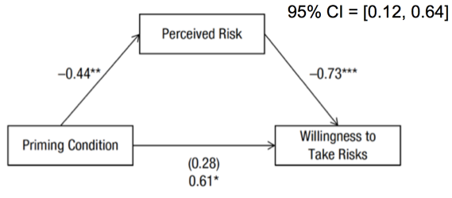

**Result from replication:**

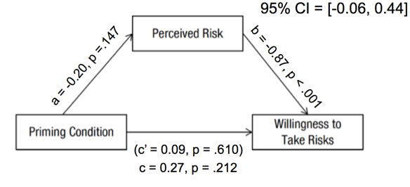

Further, although the original authors did not exclude any participants on the basis of time spent reading the priming excerpt, I also ran all my analyses on participants who spent at least 5 seconds reading the priming information (as I would not expect the priming manipulation to have an effect on participants who did not read it). The results of the replication mediation analysis reported above were the same for participants who spent at least 5 seconds reading the priming excerpt. Specifically, participants in the God condition did not report a significantly higher willingness to take risks, *b* = 0.24, *t*(143) = 1.11, *p* = .269, than participants in the control condition. Further, participants in the God condition did not perceive significantly less danger associated with these risks, *b* = -0.19, *t*(143) = -1.33, *p* = .186, than participants in the control condition. When the effects of God condition and perceived danger were both included in the model, the indirect effect (i.e., through the mediator) was not significant, (95% confidence interval, or CI = [-0.07, 0.42]), unlike the original study. The direct effect (i.e., the effect of condition independent of the mediator) remained non-significant, *b* = 0.08, *t*(142) = 0.44, *p* = .659.

### Commentary

#### Insights from Additional Confirmatory Analyses

**Preliminary Analysis: Linear Mixed Models**  
The original study found that the results of a linear mixed model that included scenario (three levels, dummy coded), condition, and the terms representing their interaction did not differ from the results of the model without the interaction, *χ2*(2, *N* = 101) = 1.24, *p* = .539, which indicates that scenario did not moderate the effect of condition on willingness to take risks.

This result was replicated, both for all participants, *χ2*(2, *N* = 154) = 1.57, *p* = .456, and for participants who spent at least 5 seconds reading the priming excerpt, *χ2*(2, *N* = 145) = 3.18, *p* = .204.

**Additional Analysis: Mediation for each scenario**  
Although the authors collapsed the perceived risk items and risk taking items across the three risky scenarios (motorcycling without a helmet, wilderness camping, and backcountry skiing) for their main mediation analysis, they showed in their Supplemental Material that the indirect effect (i.e., the effect of condition on willingness to take risks, through perceived risk) remained significant when running the mediation analysis for each scenario individually.

I also found that the indirect effect from my main mediation analysis (although non-significant in my replication) did not vary by scenario. Further, this was true both for all participants and for participants who spent at least 5 seconds reading the priming excerpt:  
**Scenario 1: Motorcycle**  
**All participants**  
95% CI = [-0.04, 0.37]  
**Participants who spent at least 5 seconds reading the prime**  
95% CI = [-0.06, 0.37]

**Scenario 3: Skiing**  
**All participants**  
95% CI = [-0.05, 0.72]  
**Participants who spent at least 5 seconds reading the prime**  
95% CI = [-0.09, 0.69]

**Additional Analysis: Mediation for each perceived risk item**  
Additionally, as the authors included in their Supplemental Material, they ran their main mediation analysis three additional times, treating each item in the perceived risk index individually as the mediating variable. The authors found that there were no significant differences between the indirect effects. Specifically, while the perceived risk index significantly mediated the effect of condition on willingness to take risks, none of the perceived risk items alone (likelihood, seriousness, and coping) significantly mediated the effect of condition on willingness to take risks (see “Analysis Plan” section for additional information).

**Perceived Risk Item: Coping**  
**All participants**  
95% CI = [0.02, 0.47]  
Note here that while participants in the God condition did not report a significantly higher willingness to take risks, *b* = 0.27, *t*(152) = 1.25, *p* = .212, participants in the God condition *did* report a greater ability to cope with these risks (ability to cope is reverse coded here), *b* = -0.47, *t*(152) = -2.20, *p* = .029, than participants in the control condition. When the effects of God condition and perceived coping ability were both included in the model, the indirect effect was significant and the direct effect remained non-significant, *b* = 0.04, *t*(151) = 0.19, *p* = .852.  
**Participants who spent at least 5 seconds reading the prime**  
95% CI = [-0.01, 0.41]

**Additional Analysis: Is there Moderation by God Belief?**  
Finally, as the authors depicted in their Supplemental Material, they did not find that belief in God moderated the effect of condition on willingness to take risks (see “Analysis Plan” section for additional information). Similarly, I did not find that belief in God moderated the effect of condition on willingness to take risks, neither for all participants (believers: *t*(77) = 0.58, *p* = .563; non-believers: *t*(73) = 1.08, *p* = .285), nor for participants who spent at least 5 seconds reading the priming excerpt (believers: *t*(75) = 0.36, *p* = .718; non-believers: *t*(66) = 1.12, *p* = .268).

#### Insights from Additional Exploratory Analyses

**Time Reading Prime as a Covariate**  
Including time spent reading the priming excerpt as a covariate did not improve the model fit in comparison to the model with only condition as a predictor of risk-taking, *F*(1, 151) = 1.91, *p* = .169.

#### Assessment of the Meaning of the Replication

Due to the fact that the original study was run on MTurk and that I used all the exact materials from the original study in my replication, I do not think that my failure to fully replicate the original study’s key result was due to the few differences between the original study and my replication. The “Differences from Original Study” section outlines that the changes I did make were either minor and/or in the service of best research practices (in order to make replicating the original study’s findings as likely as possible). Given that all the effects in the replication of the key mediation analysis were in the expected direction, I think it is most likely that the effect size from the original study was an overestimation of the actual effect size, and thus, even with 80% power, my replication was underpowered.